# Восстановление золота из руды

## Описание проекта

### Постановка задачи

**Цель:**

Подготовить прототип модели машинного обучения, которая должна предсказать коэффициент восстановления золота из золотосодержащей руды. Для решения использовать данные с параметрами добычи и очистки.

Модель поможет оптимизировать производство, чтобы не запускать предприятие с убыточными характеристиками.

**Этапы:**

1. Подготовить данные;
2. Провести исследовательский анализ данных;
3. Построить и обучить модель.

**Данные:**

Данные находятся в трёх файлах:

- gold_recovery_train_new.csv — обучающая выборка;
- gold_recovery_test_new.csv — тестовая выборка;
- gold_recovery_full_new.csv — исходные данные.

Данные индексируются датой и временем получения информации (признак date). Соседние по времени параметры часто похожи. Некоторые параметры недоступны, потому что замеряются и/или рассчитываются значительно позже. Из-за этого в тестовой выборке отсутствуют некоторые признаки, которые могут быть в обучающей. Также в тестовом наборе нет целевых признаков. Исходный датасет содержит обучающую и тестовую выборки со всеми признаками.

В нашем распоряжении сырые данные: их просто выгрузили из хранилища. Прежде чем приступить к построению модели, необходимо проверить их на корректность.

**Описание данных**

Технологический процесс

- Rougher feed — исходное сырье
- Rougher additions (или reagent additions) — флотационные реагенты: Xanthate, Sulphate, Depressant
  - Xanthate **— ксантогенат (промотер, или активатор флотации);
  - Sulphate — сульфат (на данном производстве сульфид натрия);
  - Depressant — депрессант (силикат натрия).
- Rougher process (англ. «грубый процесс») — флотация
- Rougher tails — отвальные хвосты
- Float banks — флотационная установка
- Cleaner process — очистка
- Rougher Au — черновой концентрат золота
- Final Au — финальный концентрат золота

Параметры этапов

- air amount — объём воздуха
- fluid levels — уровень жидкости
- feed size — размер гранул сырья
- feed rate — скорость подачи
- Наименование признаков

Наименование признаков должно быть такое:

- [этап].[тип_параметра].[название_параметра]  
  Пример: rougher.input.feed_ag

Возможные значения для блока [этап]:

- rougher — флотация
- primary_cleaner — первичная очистка
- secondary_cleaner — вторичная очистка
- final — финальные характеристики

Возможные значения для блока [тип_параметра]:

- input — параметры сырья
- output — параметры продукта
- state — параметры, характеризующие текущее состояние этапа
- calculation — расчётные характеристики

**Схема технологического процесса:**

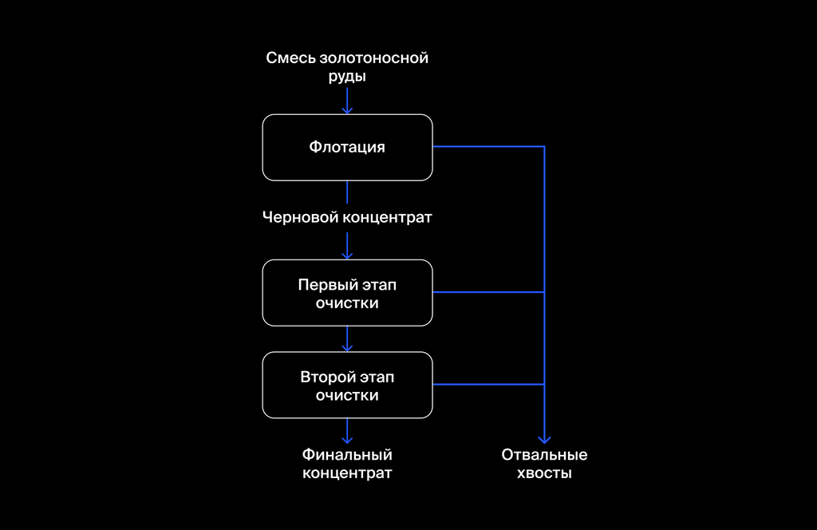

### План выполнения

1. Подготовить данные
- Открыть файлы и изучите их.
- Проверить, что эффективность обогащения рассчитана правильно. Вычислить её на обучающей выборке для признака rougher.output.recovery. Найти MAE между расчетными значениями и значением признака.
- Анализ признаков, недоступных в тестовой выборке. Что это за параметры? К какому типу относятся?
- Предобработка данных.
1. Анализ данных
- Как меняется концентрация металлов (Au, Ag, Pb) на различных этапах очистки?
- Сравнение распределения размеров гранул сырья на обучающей и тестовой выборках. Если распределения сильно отличаются друг от друга, оценка модели будет неправильной.
- Исследование суммарной концентрацию всех веществ на разных стадиях: в сырье, в черновом и финальном концентратах.
1. Постройка модели
- Функция для вычисления итоговой sMAPE.
- Обучение различных моделей и оценка их качества кросс-валидацией. Выбор лучшей модели и проверка её на тестовой выборке.
1. Общие выводы

## Стартовые параметры и ввод данных

```python
# устноавка нестандартных библиотек

! pip install phik --quiet
! pip install catboost --quiet
! pip install xgboost --quiet
! pip install shap --quiet
```

```python
# Подключаем необходимые библиотеки

import pandas as pd
pd.options.mode.chained_assignment = None # чтобы пофиксить ошибку при масштабировании данных в sklearn

import matplotlib.pyplot as plt
import seaborn as sns
import os
import numpy as np
from scipy import stats as st

from sklearn.model_selection import train_test_split
from sklearn import linear_model
from sklearn.utils import shuffle
from sklearn.preprocessing import StandardScaler

from sklearn.linear_model import LinearRegression, RidgeCV
from sklearn.dummy import DummyRegressor
from sklearn.neighbors import KNeighborsRegressor
from catboost import CatBoostRegressor
from xgboost import XGBRegressor
from sklearn.multioutput import MultiOutputRegressor

from catboost import cv as catb_cv
from catboost import Pool
from sklearn.model_selection import KFold
from sklearn.model_selection import cross_val_score
from sklearn.metrics import (accuracy_score, confusion_matrix, ConfusionMatrixDisplay, f1_score,
                             roc_auc_score, roc_curve, recall_score, precision_score,
                             mean_squared_error, mean_absolute_error, make_scorer)

import phik
import shap

%matplotlib inline

pd.options.display.float_format = '{:.2f}'.format # отображать 2 знака после запятой
pd.options.display.max_columns = 50 # отображать до 50 колонок
pd.set_option('display.max_colwidth', 130) # увеличиваем максимальную ширину столбца, чтобы видеть больше данных (будут адреса)

from sklearn.linear_model import LinearRegression
```

```python
# Вводим классы для возможности лучшей визуализации
class color:
   BLUE = '\033[94m'
   GREEN = '\033[92m'
   RED = '\033[91m'
   BOLD = '\033[1m'
   UNDERLINE = '\033[4m'
   END = '\033[0m'
```

```python
# Функция загрузки данных из csv.
# На вход функция принимает два варианта пути (локальный/сервер). Загрузка происходит из доступного.
# Нам известно, что колонка с индексом 0 содержит индексы
def import_data(pth_1, pth_2):
    if os.path.exists(pth_1):
        return pd.read_csv(pth_1, sep=',', index_col=0, parse_dates=True)
    elif os.path.exists(pth_2):
        return pd.read_csv(pth_2, sep=',', index_col=0, parse_dates=True)
    else:
        print('Загрузка данных неудачно. Нужно проверить, что пошло не так.')
```

```python
# Загружаем данные из 3-х источников
df_train = import_data('/datasets/gold_recovery_train_new.csv',
                  r'C:\Python\ml_gold\gold_recovery_train_new.csv')
df_test = import_data('/datasets/gold_recovery_test_new.csv',
                  r'C:\Python\ml_gold\gold_recovery_test_new.csv')
df_full = import_data('/datasets/gold_recovery_full_new.csv',
                  r'C:\Python\ml_gold\gold_recovery_full_new.csv')
```

```python
#Смотрим результат:
display(df_train.head())
display(df_test.head())
display(df_full.head())
```

| date | final.output.concentrate_ag | final.output.concentrate_pb | final.output.concentrate_sol | final.output.concentrate_au | final.output.recovery | final.output.tail_ag | final.output.tail_pb | final.output.tail_sol | final.output.tail_au | primary_cleaner.input.sulfate | primary_cleaner.input.depressant | primary_cleaner.input.feed_size | primary_cleaner.input.xanthate | primary_cleaner.output.concentrate_ag | primary_cleaner.output.concentrate_pb | primary_cleaner.output.concentrate_sol | primary_cleaner.output.concentrate_au | primary_cleaner.output.tail_ag | primary_cleaner.output.tail_pb | primary_cleaner.output.tail_sol | primary_cleaner.output.tail_au | primary_cleaner.state.floatbank8_a_air | primary_cleaner.state.floatbank8_a_level | primary_cleaner.state.floatbank8_b_air | primary_cleaner.state.floatbank8_b_level | ... | rougher.state.floatbank10_e_level | rougher.state.floatbank10_f_air | rougher.state.floatbank10_f_level | … |
| --- | --- | --- | --- | --- | --- | --- | --- | --- | --- | --- | --- | --- | --- | --- | --- | --- | --- | --- | --- | --- | --- | --- | --- | --- | --- | --- | --- | --- | --- | --- |
| 2016-01-15 00:00:00 | 6.06 | 9.89 | 5.51 | 42.19 | 70.54 | 10.41 | 0.90 | 16.90 | 2.14 | 127.09 | 10.13 | 7.25 | 0.99 | 8.55 | 10.39 | 19.53 | 34.17 | 14.94 | 2.53 | 7.48 | 2.11 | 1549.78 | -498.91 | 1551.43 | -516.40 | ... | -455.46 | 1416.35 | -451.94 | … |
| 2016-01-15 01:00:00 | 6.03 | 9.97 | 5.26 | 42.70 | 69.27 | 10.46 | 0.93 | 16.63 | 2.22 | 125.63 | 10.30 | 7.25 | 1.00 | 8.56 | 10.50 | 19.37 | 34.12 | 16.25 | 3.05 | 6.73 | 2.35 | 1576.17 | -500.90 | 1575.95 | -499.87 | ... | -450.87 | 1399.72 | -450.12 | … |
| 2016-01-15 02:00:00 | 6.06 | 10.21 | 5.38 | 42.66 | 68.12 | 10.51 | 0.95 | 16.21 | 2.26 | 123.82 | 11.32 | 7.25 | 0.99 | 8.60 | 10.35 | 19.17 | 33.97 | 16.49 | 3.12 | 6.47 | 2.42 | 1601.56 | -500.00 | 1600.39 | -500.61 | ... | -449.94 | 1400.32 | -450.53 | … |
| 2016-01-15 03:00:00 | 6.05 | 9.98 | 4.86 | 42.69 | 68.35 | 10.42 | 0.88 | 16.53 | 2.15 | 122.27 | 11.32 | 7.25 | 1.00 | 7.22 | 8.50 | 15.98 | 28.26 | 16.02 | 2.96 | 6.84 | 2.26 | 1599.97 | -500.95 | 1600.66 | -499.68 | ... | -450.03 | 1400.23 | -449.79 | … |
| 2016-01-15 04:00:00 | 6.15 | 10.14 | 4.94 | 42.77 | 66.93 | 10.36 | 0.79 | 16.53 | 2.06 | 117.99 | 11.91 | 7.25 | 1.01 | 9.09 | 9.99 | 19.20 | 33.04 | 16.48 | 3.11 | 6.55 | 2.28 | 1601.34 | -498.98 | 1601.44 | -500.32 | ... | -448.88 | 1401.16 | -450.41 | … |

5 rows × 86 columns

| date | primary_cleaner.input.sulfate | primary_cleaner.input.depressant | primary_cleaner.input.feed_size | primary_cleaner.input.xanthate | primary_cleaner.state.floatbank8_a_air | primary_cleaner.state.floatbank8_a_level | primary_cleaner.state.floatbank8_b_air | primary_cleaner.state.floatbank8_b_level | primary_cleaner.state.floatbank8_c_air | primary_cleaner.state.floatbank8_c_level | primary_cleaner.state.floatbank8_d_air | primary_cleaner.state.floatbank8_d_level | rougher.input.feed_ag | rougher.input.feed_pb | rougher.input.feed_rate | rougher.input.feed_size | rougher.input.feed_sol | rougher.input.feed_au | rougher.input.floatbank10_sulfate | rougher.input.floatbank10_xanthate | rougher.input.floatbank11_sulfate | rougher.input.floatbank11_xanthate | rougher.state.floatbank10_a_air | rougher.state.floatbank10_a_level | rougher.state.floatbank10_b_air | ... | rougher.state.floatbank10_c_level | rougher.state.floatbank10_d_air | rougher.state.floatbank10_d_level | … |
| --- | --- | --- | --- | --- | --- | --- | --- | --- | --- | --- | --- | --- | --- | --- | --- | --- | --- | --- | --- | --- | --- | --- | --- | --- | --- | --- | --- | --- | --- | --- |
| 2016-09-01 00:59:59 | 210.80 | 14.99 | 8.08 | 1.01 | 1398.98 | -500.23 | 1399.14 | -499.92 | 1400.10 | -500.70 | 1399.00 | -499.49 | 13.13 | 5.64 | 489.79 | 62.71 | 42.02 | 12.08 | 16.92 | 6.15 | 16.87 | 6.15 | 1001.85 | -350.30 | 1249.74 | ... | -399.40 | 1198.29 | -399.49 | … |
| 2016-09-01 01:59:59 | 215.39 | 14.99 | 8.08 | 0.99 | 1398.78 | -500.06 | 1398.06 | -499.78 | 1396.15 | -499.24 | 1399.51 | -500.42 | 13.04 | 5.53 | 490.10 | 61.96 | 41.19 | 11.92 | 17.00 | 6.00 | 17.00 | 6.00 | 998.69 | -350.43 | 1248.40 | ... | -399.63 | 1200.51 | -399.94 | … |
| 2016-09-01 02:59:59 | 215.26 | 12.88 | 7.79 | 1.00 | 1398.49 | -500.87 | 1398.86 | -499.76 | 1398.08 | -502.15 | 1399.50 | -499.72 | 13.14 | 5.43 | 489.62 | 66.90 | 42.55 | 12.09 | 16.99 | 5.85 | 16.98 | 5.85 | 998.52 | -349.78 | 1247.44 | ... | -401.07 | 1199.77 | -400.79 | … |
| 2016-09-01 03:59:59 | 215.34 | 12.01 | 7.64 | 0.86 | 1399.62 | -498.86 | 1397.44 | -499.21 | 1400.13 | -498.36 | 1401.07 | -501.04 | 12.40 | 5.11 | 476.62 | 59.87 | 41.06 | 12.18 | 16.53 | 5.80 | 16.52 | 5.80 | 1000.28 | -350.17 | 1251.32 | ... | -399.75 | 1199.40 | -397.50 | … |
| 2016-09-01 04:59:59 | 199.10 | 10.68 | 7.53 | 0.81 | 1401.27 | -500.81 | 1398.13 | -499.50 | 1402.17 | -500.81 | 1399.48 | -499.37 | 11.33 | 4.77 | 488.25 | 63.32 | 41.27 | 11.29 | 13.61 | 5.74 | 13.65 | 5.74 | 996.54 | -350.56 | 1304.66 | ... | -399.05 | 1248.70 | -400.88 | … |

5 rows × 52 columns

| date | final.output.concentrate_ag | final.output.concentrate_pb | final.output.concentrate_sol | final.output.concentrate_au | final.output.recovery | final.output.tail_ag | final.output.tail_pb | final.output.tail_sol | final.output.tail_au | primary_cleaner.input.sulfate | primary_cleaner.input.depressant | primary_cleaner.input.feed_size | primary_cleaner.input.xanthate | primary_cleaner.output.concentrate_ag | primary_cleaner.output.concentrate_pb | primary_cleaner.output.concentrate_sol | primary_cleaner.output.concentrate_au | primary_cleaner.output.tail_ag | primary_cleaner.output.tail_pb | primary_cleaner.output.tail_sol | primary_cleaner.output.tail_au | primary_cleaner.state.floatbank8_a_air | primary_cleaner.state.floatbank8_a_level | primary_cleaner.state.floatbank8_b_air | primary_cleaner.state.floatbank8_b_level | ... | rougher.state.floatbank10_e_level | rougher.state.floatbank10_f_air | rougher.state.floatbank10_f_level | … |
| --- | --- | --- | --- | --- | --- | --- | --- | --- | --- | --- | --- | --- | --- | --- | --- | --- | --- | --- | --- | --- | --- | --- | --- | --- | --- | --- | --- | --- | --- | --- |
| 2016-01-15 00:00:00 | 6.06 | 9.89 | 5.51 | 42.19 | 70.54 | 10.41 | 0.90 | 16.90 | 2.14 | 127.09 | 10.13 | 7.25 | 0.99 | 8.55 | 10.39 | 19.53 | 34.17 | 14.94 | 2.53 | 7.48 | 2.11 | 1549.78 | -498.91 | 1551.43 | -516.40 | ... | -455.46 | 1416.35 | -451.94 | … |
| 2016-01-15 01:00:00 | 6.03 | 9.97 | 5.26 | 42.70 | 69.27 | 10.46 | 0.93 | 16.63 | 2.22 | 125.63 | 10.30 | 7.25 | 1.00 | 8.56 | 10.50 | 19.37 | 34.12 | 16.25 | 3.05 | 6.73 | 2.35 | 1576.17 | -500.90 | 1575.95 | -499.87 | ... | -450.87 | 1399.72 | -450.12 | … |
| 2016-01-15 02:00:00 | 6.06 | 10.21 | 5.38 | 42.66 | 68.12 | 10.51 | 0.95 | 16.21 | 2.26 | 123.82 | 11.32 | 7.25 | 0.99 | 8.60 | 10.35 | 19.17 | 33.97 | 16.49 | 3.12 | 6.47 | 2.42 | 1601.56 | -500.00 | 1600.39 | -500.61 | ... | -449.94 | 1400.32 | -450.53 | … |
| 2016-01-15 03:00:00 | 6.05 | 9.98 | 4.86 | 42.69 | 68.35 | 10.42 | 0.88 | 16.53 | 2.15 | 122.27 | 11.32 | 7.25 | 1.00 | 7.22 | 8.50 | 15.98 | 28.26 | 16.02 | 2.96 | 6.84 | 2.26 | 1599.97 | -500.95 | 1600.66 | -499.68 | ... | -450.03 | 1400.23 | -449.79 | … |
| 2016-01-15 04:00:00 | 6.15 | 10.14 | 4.94 | 42.77 | 66.93 | 10.36 | 0.79 | 16.53 | 2.06 | 117.99 | 11.91 | 7.25 | 1.01 | 9.09 | 9.99 | 19.20 | 33.04 | 16.48 | 3.11 | 6.55 | 2.28 | 1601.34 | -498.98 | 1601.44 | -500.32 | ... | -448.88 | 1401.16 | -450.41 | … |

5 rows × 86 columns

## Подготовка данных

### Основные функции

#### Фуникция первичного знакомства с данными

```python
# Фуникция первичного знакомства с данными
# Функция, которая сразу выводит всю информацию, принимая на вход название датасета
def data_view(data):
    #Сразу приводим названия всех колонок к змеиному регистру.
    data.columns = data.columns. \
                                str.replace(r'([a-z0-9])([A-Z])' , r'\1_\2', regex = True). \
                                str.replace(r'(.)([A-Z][a-z]+)', r'\1_\2', regex = True). \
                                str.replace(r'([a-z0-9])([A-Z])', r'\1_\2', regex = True). \
                                str.replace(r'__([A-Z])', r'_\1', regex = True). \
                                str.replace(r'__([a-z0-9])', r'_\1', regex = True)
    data.columns = data.columns.str.lower()
    print()
    print(color.BLUE + color.BOLD + 'Первые 5 строк данных' + color.END)
    display(data.head()) # Выводим первые 5 строк
    print()
    print(color.BLUE + color.BOLD + 'Последние 5 строк данных' + color.END)
    display(data.tail()) # Выводим последние 5 строк
    print()
    print(color.BLUE + color.BOLD + 'Информация по датасету' + color.END)
    print()
    display(data.info()) # Выводим инфо по датасету
    print()
    # Уточняем количество пропусков по столбцам. Берем сумму пропусков и процентную долю пропусков
    print(color.BLUE + color.BOLD + 'Пропуски и уникальные значения (без учета пропусков)' + color.END)
    display(pd.concat([data.isna().sum().rename('nan_count'),
                       data.isna().mean().rename('nan_percent'),
                       data.nunique().rename('unique_values')],
                      axis=1).style.format({'nan_percent' : '{:.2%}'}))
    print()
    print(color.BLUE + color.BOLD + 'Дубликаты' + color.END)
    print()
    print('Количество явных дубликатов:', data.duplicated().sum())
    print('Доля явных дубликатов в данных: {:.2%}'.format((data.duplicated().sum())/len(data)))
```

#### Фуникция подсчета пустых значений

```python
# Фуникция подсчета пустых значений
def nan_count(data):
    # Уточняем количество пропусков по столбцам. Берем сумму пропусков и процентную долю пропусков
    print(color.BLUE + color.BOLD + 'Пропуски и уникальные значения (без учета пропусков)' + color.END)
    display(pd.concat([data.isna().sum().rename('nan_count'),
                       data.isna().mean().rename('nan_percent'),
                       data.nunique().rename('unique_values')],
                      axis=1).style.format({'nan_percent' : '{:.2%}'}))
```

#### Фуникция заполнения пропусков по ближайшему значению

```python
# Функция заполнения пропусков по ближайшему значению
def nan_fix(df):
    for col in df.columns:
        # Заполняем пропуски ближайшими значениями
        df[col] = df[col].fillna(method='ffill')

    # Смотрим результат
    nan_count(df)
```

#### Фуникция визуализации распределения значений

```python
# Функция строит гистограммы. На вход принимает датасет и кол-во столбцов в subplot
def show_hist(df, columns, k_height):
    # задаем размер графика
    plt.figure(figsize=(17, df.columns.nunique()*k_height))
    # перебираем все параметры-колонки
    for i, col in enumerate(df.columns):
        # для наглядности выводим гистограммы в subplot. Параметр позиции вывода берем +1, т.к. индексы в i идут с 0
        df[col].hist(bins=30, ec='black', alpha=0.5,
                          ax=plt.subplot(int(df.columns.nunique()/columns+1), columns, i+1))
        # рисуем отметку среднего
        plt.axvline(df[col].describe()['mean'], color='r',
                    linestyle='dashed', linewidth=2)
        # рисуем отметку медианы + выводим ее количественное значение
        plt.axvline(df[col].describe()['50%'], color='b',
                    linestyle='dotted', linewidth=2)
        plt.title(f'{col}', fontsize = 14)
    plt.tight_layout()
    plt.show()
```

#### Функция оптимизации занимаемой памяти

```python
def mem_usage(pandas_obj):
    '''Функция, измеряющая объем памяти, занимаемый датафреймом'''
    if isinstance(pandas_obj,pd.DataFrame):
        usage_b = pandas_obj.memory_usage(deep=True).sum()
    else: # исходим из предположения о том, что если это не DataFrame, то это Series
        usage_b = pandas_obj.memory_usage(deep=True)
    usage_mb = usage_b / 1024 # преобразуем байты в килобайты
    return round(usage_mb, 2)
```

```python
def data_optimize(df, object_option=False):
    '''
    Функция сокращающая объем занимаемой памяти входящего в нее датафрейма

    параметры
    ----------
    df: входящий датафрейм для оптимизации
    object_option : принимает значения True и False
        в случае true, конвертирует object в category

    возвращает
    -------
    df: датафрейм с оптимизированными типами данных
    '''

    print(color.BOLD + f'Объем памяти, занимаемый датафреймом до оптимизации {mem_usage(df)} Kb' + color.END)
    for col in df.columns:
        # для столбцов с типом данных int пробегаем и смотрим максимальное значение, оптимизируем тип
        if df[col].dtype == 'int':
            col_min = df[col].min()
            col_max = df[col].max()
            if col_min >= 0:
                if col_max < np.iinfo(np.uint8).max:
                    df[col] = df[col].astype(np.int16)
                elif col_max < np.iinfo(np.uint16).max:
                    df[col] = df[col].astype(np.uint16)
                elif col_max < np.iinfo(np.uint32).max:
                    df[col] = df[col].astype(np.uint32)
                else:
                    df[col] = df[col]
            else:
                if col_max < np.iinfo(np.int8).max and col_min > np.iinfo(np.int16).min:
                    df[col] = df[col].astype(np.int8)
                elif col_max < np.iinfo(np.int16).max and col_min > np.iinfo(np.int16).min:
                    df[col] = df[col].astype(np.int16)
                elif col_max < np.iinfo(np.int32).max and col_min > np.iinfo(np.int32).min:
                    df[col] = df[col].astype(np.int32)
                else:
                    df[col] = df[col]

        # для столбцов с типом данных float пробегаем и смотрим максимальное значение, оптимизируем тип
        elif df[col].dtype == 'float':
            col_min = df[col].min()
            col_max = df[col].max()
            if col_min > np.finfo(np.float32).min and col_max < np.finfo(np.float32).max:
                df[col] = df[col].astype(np.float32)
            else:
                df[col] = df[col]

        if object_option:
            if df[col].dtype == 'object':
                if len(df[col].value_counts()) < 0.5 * df.shape[0]:
                    df[col] = df[col].astype('category')
    print(color.BOLD + color.BLUE + f'Объем памяти, занимаемый датафреймом после оптимизации {mem_usage(df)} Mb' + color.END)
    return df.info()
```

### Знакомство с данными

#### Датасет - исходные данные. Первичный обзор

```python
data_view(df_full)
```

```
Первые 5 строк данных
```

| date | final.output.concentrate_ag | final.output.concentrate_pb | final.output.concentrate_sol | final.output.concentrate_au | final.output.recovery | final.output.tail_ag | final.output.tail_pb | final.output.tail_sol | final.output.tail_au | primary_cleaner.input.sulfate | primary_cleaner.input.depressant | primary_cleaner.input.feed_size | primary_cleaner.input.xanthate | primary_cleaner.output.concentrate_ag | primary_cleaner.output.concentrate_pb | primary_cleaner.output.concentrate_sol | primary_cleaner.output.concentrate_au | primary_cleaner.output.tail_ag | primary_cleaner.output.tail_pb | primary_cleaner.output.tail_sol | primary_cleaner.output.tail_au | primary_cleaner.state.floatbank8_a_air | primary_cleaner.state.floatbank8_a_level | primary_cleaner.state.floatbank8_b_air | primary_cleaner.state.floatbank8_b_level | ... | rougher.state.floatbank10_e_level | rougher.state.floatbank10_f_air | rougher.state.floatbank10_f_level | … |
| --- | --- | --- | --- | --- | --- | --- | --- | --- | --- | --- | --- | --- | --- | --- | --- | --- | --- | --- | --- | --- | --- | --- | --- | --- | --- | --- | --- | --- | --- | --- |
| 2016-01-15 00:00:00 | 6.06 | 9.89 | 5.51 | 42.19 | 70.54 | 10.41 | 0.90 | 16.90 | 2.14 | 127.09 | 10.13 | 7.25 | 0.99 | 8.55 | 10.39 | 19.53 | 34.17 | 14.94 | 2.53 | 7.48 | 2.11 | 1549.78 | -498.91 | 1551.43 | -516.40 | ... | -455.46 | 1416.35 | -451.94 | … |
| 2016-01-15 01:00:00 | 6.03 | 9.97 | 5.26 | 42.70 | 69.27 | 10.46 | 0.93 | 16.63 | 2.22 | 125.63 | 10.30 | 7.25 | 1.00 | 8.56 | 10.50 | 19.37 | 34.12 | 16.25 | 3.05 | 6.73 | 2.35 | 1576.17 | -500.90 | 1575.95 | -499.87 | ... | -450.87 | 1399.72 | -450.12 | … |
| 2016-01-15 02:00:00 | 6.06 | 10.21 | 5.38 | 42.66 | 68.12 | 10.51 | 0.95 | 16.21 | 2.26 | 123.82 | 11.32 | 7.25 | 0.99 | 8.60 | 10.35 | 19.17 | 33.97 | 16.49 | 3.12 | 6.47 | 2.42 | 1601.56 | -500.00 | 1600.39 | -500.61 | ... | -449.94 | 1400.32 | -450.53 | … |
| 2016-01-15 03:00:00 | 6.05 | 9.98 | 4.86 | 42.69 | 68.35 | 10.42 | 0.88 | 16.53 | 2.15 | 122.27 | 11.32 | 7.25 | 1.00 | 7.22 | 8.50 | 15.98 | 28.26 | 16.02 | 2.96 | 6.84 | 2.26 | 1599.97 | -500.95 | 1600.66 | -499.68 | ... | -450.03 | 1400.23 | -449.79 | … |
| 2016-01-15 04:00:00 | 6.15 | 10.14 | 4.94 | 42.77 | 66.93 | 10.36 | 0.79 | 16.53 | 2.06 | 117.99 | 11.91 | 7.25 | 1.01 | 9.09 | 9.99 | 19.20 | 33.04 | 16.48 | 3.11 | 6.55 | 2.28 | 1601.34 | -498.98 | 1601.44 | -500.32 | ... | -448.88 | 1401.16 | -450.41 | … |

5 rows × 86 columns

```
Последние 5 строк данных
```

| date | final.output.concentrate_ag | final.output.concentrate_pb | final.output.concentrate_sol | final.output.concentrate_au | final.output.recovery | final.output.tail_ag | final.output.tail_pb | final.output.tail_sol | final.output.tail_au | primary_cleaner.input.sulfate | primary_cleaner.input.depressant | primary_cleaner.input.feed_size | primary_cleaner.input.xanthate | primary_cleaner.output.concentrate_ag | primary_cleaner.output.concentrate_pb | primary_cleaner.output.concentrate_sol | primary_cleaner.output.concentrate_au | primary_cleaner.output.tail_ag | primary_cleaner.output.tail_pb | primary_cleaner.output.tail_sol | primary_cleaner.output.tail_au | primary_cleaner.state.floatbank8_a_air | primary_cleaner.state.floatbank8_a_level | primary_cleaner.state.floatbank8_b_air | primary_cleaner.state.floatbank8_b_level | ... | rougher.state.floatbank10_e_level | rougher.state.floatbank10_f_air | rougher.state.floatbank10_f_level | … |
| --- | --- | --- | --- | --- | --- | --- | --- | --- | --- | --- | --- | --- | --- | --- | --- | --- | --- | --- | --- | --- | --- | --- | --- | --- | --- | --- | --- | --- | --- | --- |
| 2018-08-18 06:59:59 | 3.22 | 11.36 | 6.80 | 46.71 | 73.76 | 8.77 | 3.14 | 10.40 | 1.53 | 123.38 | 8.03 | 6.50 | 1.30 | 6.56 | 12.45 | 7.06 | 32.94 | 22.85 | 6.53 | 3.93 | 2.31 | 1648.42 | -400.38 | 1648.74 | -400.36 | ... | -499.21 | 849.76 | -497.45 | … |
| 2018-08-18 07:59:59 | 3.20 | 11.35 | 6.86 | 46.87 | 69.05 | 8.90 | 3.13 | 10.55 | 1.61 | 120.88 | 7.96 | 6.50 | 1.30 | 6.61 | 12.62 | 7.54 | 32.93 | 23.00 | 6.63 | 4.09 | 2.46 | 1649.82 | -399.93 | 1649.36 | -399.72 | ... | -500.29 | 850.01 | -496.82 | … |
| 2018-08-18 08:59:59 | 3.11 | 11.43 | 6.89 | 46.80 | 67.00 | 8.53 | 2.91 | 11.12 | 1.60 | 105.67 | 7.96 | 6.50 | 1.32 | 7.13 | 12.63 | 7.94 | 31.86 | 22.30 | 6.28 | 4.46 | 2.61 | 1649.17 | -399.89 | 1649.20 | -399.68 | ... | -500.51 | 850.46 | -506.90 | … |
| 2018-08-18 09:59:59 | 3.37 | 11.63 | 6.80 | 46.41 | 65.52 | 8.78 | 2.82 | 10.46 | 1.60 | 98.88 | 7.98 | 6.50 | 1.24 | 7.49 | 12.01 | 6.94 | 30.77 | 22.71 | 6.25 | 3.56 | 2.80 | 1646.55 | -398.98 | 1648.21 | -400.38 | ... | -499.04 | 851.35 | -499.12 | … |
| 2018-08-18 10:59:59 | 3.60 | 11.74 | 6.72 | 46.30 | 70.28 | 8.41 | 2.52 | 10.65 | 1.39 | 95.25 | 8.08 | 6.50 | 1.28 | 7.54 | 11.65 | 6.20 | 30.36 | 22.74 | 6.08 | 3.03 | 2.71 | 1648.76 | -399.86 | 1650.14 | -399.96 | ... | -499.26 | 850.11 | -499.41 | … |

5 rows × 86 columns

```
Информация по датасету

<class 'pandas.core.frame.DataFrame'>
DatetimeIndex: 19439 entries, 2016-01-15 00:00:00 to 2018-08-18 10:59:59
Data columns (total 86 columns):
 #   Column                                              Non-Null Count  Dtype
---  ------                                              --------------  -----
 0   final.output.concentrate_ag                         19438 non-null  float64
 1   final.output.concentrate_pb                         19438 non-null  float64
 2   final.output.concentrate_sol                        19228 non-null  float64
 3   final.output.concentrate_au                         19439 non-null  float64
 4   final.output.recovery                               19439 non-null  float64
 5   final.output.tail_ag                                19438 non-null  float64
 6   final.output.tail_pb                                19338 non-null  float64
 7   final.output.tail_sol                               19433 non-null  float64
```

[output cut: 80 more lines]

```
None
```

```
Пропуски и уникальные значения (без учета пропусков)
```

|  | nan_count | nan_percent | unique_values |
| --- | --- | --- | --- |
| final.output.concentrate_ag | 1 | 0.01% | 19307 |
| final.output.concentrate_pb | 1 | 0.01% | 19276 |
| final.output.concentrate_sol | 211 | 1.09% | 19093 |
| final.output.concentrate_au | 0 | 0.00% | 19308 |
| final.output.recovery | 0 | 0.00% | 19235 |
| final.output.tail_ag | 1 | 0.01% | 19328 |
| final.output.tail_pb | 101 | 0.52% | 19228 |
| final.output.tail_sol | 6 | 0.03% | 19322 |
| final.output.tail_au | 0 | 0.00% | 19329 |
| primary_cleaner.input.sulfate | 24 | 0.12% | 19415 |
| primary_cleaner.input.depressant | 37 | 0.19% | 19393 |
| primary_cleaner.input.feed_size | 0 | 0.00% | 5022 |
| primary_cleaner.input.xanthate | 104 | 0.54% | 19335 |
| primary_cleaner.output.concentrate_ag | 0 | 0.00% | 19199 |
| primary_cleaner.output.concentrate_pb | 116 | 0.60% | 19055 |
| primary_cleaner.output.concentrate_sol | 370 | 1.90% | 18826 |
| primary_cleaner.output.concentrate_au | 0 | 0.00% | 19199 |
| primary_cleaner.output.tail_ag | 4 | 0.02% | 19287 |
| primary_cleaner.output.tail_pb | 21 | 0.11% | 19270 |
| primary_cleaner.output.tail_sol | 62 | 0.32% | 19229 |
| primary_cleaner.output.tail_au | 0 | 0.00% | 19291 |
| primary_cleaner.state.floatbank8_a_air | 4 | 0.02% | 19435 |
| primary_cleaner.state.floatbank8_a_level | 1 | 0.01% | 19438 |
| primary_cleaner.state.floatbank8_b_air | 4 | 0.02% | 19435 |
| primary_cleaner.state.floatbank8_b_level | 1 | 0.01% | 19438 |
| primary_cleaner.state.floatbank8_c_air | 2 | 0.01% | 19437 |
| primary_cleaner.state.floatbank8_c_level | 1 | 0.01% | 19438 |
| primary_cleaner.state.floatbank8_d_air | 3 | 0.02% | 19436 |
| primary_cleaner.state.floatbank8_d_level | 1 | 0.01% | 19438 |
| rougher.calculation.sulfate_to_au_concentrate | 2 | 0.01% | 19437 |

[output cut: 56 more lines]

```
Дубликаты

Количество явных дубликатов: 0
Доля явных дубликатов в данных: 0.00%
```

**Наблюдения:**

- В нашем распоряжении достаточно большой датасет - 19439 строк данных и 86 столбцов значений
- Встречаются пропуски в значениях некоторых признаков. В каждом признаке относительно всего объема процент пропусков незначительный (за исключением `secondary_cleaner.output.tail_sol` - 8.99% пропусков), но если удалить пропуски по всех признаках, мы потеряем значительный объем данных. В условии задачи сказано, что соседние по времени параметры часто похожи. Поэтому наиболее оптимальным представляется решение - заменить пропуски значениями ближайших соседей. Так мы устраним проблему пропусков и не внесем погрешность в процесс обучения модели.
- Можно оптимизировать тип к float32, чтобы уменьшить потребление памяти

#### Датасет - исходные данные. Работа с пропусками

```python
nan_fix(df_full)
```

```
Пропуски и уникальные значения (без учета пропусков)
```

|  | nan_count | nan_percent | unique_values |
| --- | --- | --- | --- |
| final.output.concentrate_ag | 0 | 0.00% | 19307 |
| final.output.concentrate_pb | 0 | 0.00% | 19276 |
| final.output.concentrate_sol | 0 | 0.00% | 19093 |
| final.output.concentrate_au | 0 | 0.00% | 19308 |
| final.output.recovery | 0 | 0.00% | 19235 |
| final.output.tail_ag | 0 | 0.00% | 19328 |
| final.output.tail_pb | 0 | 0.00% | 19228 |
| final.output.tail_sol | 0 | 0.00% | 19322 |
| final.output.tail_au | 0 | 0.00% | 19329 |
| primary_cleaner.input.sulfate | 0 | 0.00% | 19415 |
| primary_cleaner.input.depressant | 0 | 0.00% | 19393 |
| primary_cleaner.input.feed_size | 0 | 0.00% | 5022 |
| primary_cleaner.input.xanthate | 0 | 0.00% | 19335 |
| primary_cleaner.output.concentrate_ag | 0 | 0.00% | 19199 |
| primary_cleaner.output.concentrate_pb | 0 | 0.00% | 19055 |
| primary_cleaner.output.concentrate_sol | 0 | 0.00% | 18826 |
| primary_cleaner.output.concentrate_au | 0 | 0.00% | 19199 |
| primary_cleaner.output.tail_ag | 0 | 0.00% | 19287 |
| primary_cleaner.output.tail_pb | 0 | 0.00% | 19270 |
| primary_cleaner.output.tail_sol | 0 | 0.00% | 19229 |
| primary_cleaner.output.tail_au | 0 | 0.00% | 19291 |
| primary_cleaner.state.floatbank8_a_air | 0 | 0.00% | 19435 |
| primary_cleaner.state.floatbank8_a_level | 0 | 0.00% | 19438 |
| primary_cleaner.state.floatbank8_b_air | 0 | 0.00% | 19435 |
| primary_cleaner.state.floatbank8_b_level | 0 | 0.00% | 19438 |
| primary_cleaner.state.floatbank8_c_air | 0 | 0.00% | 19437 |
| primary_cleaner.state.floatbank8_c_level | 0 | 0.00% | 19438 |
| primary_cleaner.state.floatbank8_d_air | 0 | 0.00% | 19436 |
| primary_cleaner.state.floatbank8_d_level | 0 | 0.00% | 19438 |
| rougher.calculation.sulfate_to_au_concentrate | 0 | 0.00% | 19437 |

[output cut: 56 more lines]

Пропуски обработаны. Теперь можно оценить распределение количественных значений.

#### Датасет - исходные данные. Обзор количественных значений

Посмотрим количественные значения:

```python
# У нас много признаков, поэтому развернем describe() и отобразим все строки по кол-ву признаков
pd.set_option('display.max_rows', df_full.shape[0]+1)
display(df_full.describe().T)
pd.set_option('display.max_rows', 20)
```

|  | count | mean | std | min | 25% | 50% | 75% | max |
| --- | --- | --- | --- | --- | --- | --- | --- | --- |
| final.output.concentrate_ag | 19439.00 | 5.17 | 1.37 | 0.00 | 4.25 | 5.07 | 5.90 | 16.00 |
| final.output.concentrate_pb | 19439.00 | 9.98 | 1.67 | 0.00 | 9.14 | 10.10 | 11.04 | 17.03 |
| final.output.concentrate_sol | 19439.00 | 9.43 | 2.87 | 0.00 | 7.66 | 9.18 | 10.92 | 19.62 |
| final.output.concentrate_au | 19439.00 | 44.08 | 5.13 | 0.00 | 43.40 | 45.01 | 46.28 | 52.76 |
| final.output.recovery | 19439.00 | 67.05 | 10.13 | 0.00 | 63.30 | 68.17 | 72.69 | 100.00 |
| final.output.tail_ag | 19439.00 | 9.69 | 2.33 | 0.00 | 8.06 | 9.74 | 11.13 | 19.55 |
| final.output.tail_pb | 19439.00 | 2.69 | 0.96 | 0.00 | 2.03 | 2.74 | 3.33 | 5.80 |
| final.output.tail_sol | 19439.00 | 10.58 | 2.87 | 0.00 | 8.94 | 10.62 | 12.10 | 22.32 |
| final.output.tail_au | 19439.00 | 3.04 | 0.92 | 0.00 | 2.46 | 2.98 | 3.57 | 8.25 |
| primary_cleaner.input.sulfate | 19439.00 | 144.54 | 44.59 | 0.00 | 114.05 | 143.21 | 175.04 | 265.98 |
| primary_cleaner.input.depressant | 19439.00 | 8.81 | 3.30 | 0.00 | 6.07 | 8.04 | 11.01 | 40.00 |
| primary_cleaner.input.feed_size | 19439.00 | 7.31 | 0.61 | 1.08 | 6.94 | 7.28 | 7.67 | 15.50 |
| primary_cleaner.input.xanthate | 19439.00 | 1.02 | 0.52 | 0.00 | 0.70 | 0.93 | 1.21 | 4.10 |
| primary_cleaner.output.concentrate_ag | 19439.00 | 8.44 | 2.05 | 0.00 | 7.26 | 8.51 | 9.81 | 16.08 |
| primary_cleaner.output.concentrate_pb | 19439.00 | 9.81 | 2.57 | 0.00 | 8.68 | 10.14 | 11.42 | 17.08 |
| primary_cleaner.output.concentrate_sol | 19439.00 | 10.39 | 3.97 | 0.00 | 7.79 | 10.24 | 13.39 | 22.46 |
| primary_cleaner.output.concentrate_au | 19439.00 | 32.12 | 5.63 | 0.00 | 30.46 | 32.84 | 35.05 | 45.93 |
| primary_cleaner.output.tail_ag | 19439.00 | 16.15 | 3.55 | 0.00 | 14.02 | 15.84 | 18.01 | 29.46 |
| primary_cleaner.output.tail_pb | 19439.00 | 3.43 | 1.39 | 0.00 | 2.50 | 3.27 | 4.18 | 9.63 |
| primary_cleaner.output.tail_sol | 19439.00 | 7.96 | 2.23 | 0.00 | 6.74 | 8.18 | 9.55 | 22.28 |
| primary_cleaner.output.tail_au | 19439.00 | 3.91 | 1.59 | 0.00 | 2.92 | 3.62 | 4.59 | 17.79 |
| primary_cleaner.state.floatbank8_a_air | 19439.00 | 1589.36 | 128.99 | 0.00 | 1505.13 | 1600.60 | 1697.66 | 2103.10 |
| primary_cleaner.state.floatbank8_a_level | 19439.00 | -491.20 | 32.43 | -798.64 | -500.31 | -499.93 | -499.43 | -57.20 |
| primary_cleaner.state.floatbank8_b_air | 19439.00 | 1591.36 | 131.80 | 0.00 | 1503.64 | 1600.52 | 1699.22 | 2114.91 |
| primary_cleaner.state.floatbank8_b_level | 19439.00 | -492.19 | 33.79 | -800.00 | -500.44 | -499.96 | -499.37 | -142.53 |
| primary_cleaner.state.floatbank8_c_air | 19439.00 | 1586.67 | 136.11 | 0.00 | 1500.93 | 1600.25 | 1699.48 | 2013.16 |
| primary_cleaner.state.floatbank8_c_level | 19439.00 | -491.98 | 32.71 | -799.96 | -500.70 | -499.91 | -498.86 | -150.94 |
| primary_cleaner.state.floatbank8_d_air | 19439.00 | 1542.96 | 246.26 | 0.00 | 1494.28 | 1599.45 | 1698.53 | 2398.90 |
| primary_cleaner.state.floatbank8_d_level | 19439.00 | -488.02 | 43.96 | -799.79 | -500.46 | -499.91 | -499.06 | -30.60 |
| rougher.calculation.sulfate_to_au_concentrate | 19439.00 | 42171.42 | 324345.43 | -42235197.37 | 40697.86 | 44696.48 | 48168.50 | 3428098.94 |

[output cut: 56 more lines]

**Наблюдения:**

Посмотрим визуально распределение количественных признаков:

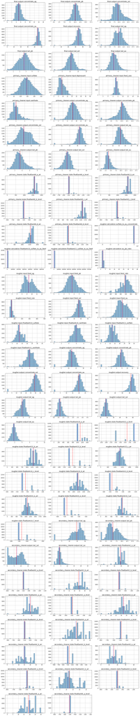

```python
# используем написанную выше функцию
show_hist(df_full, 3, 1)
```

**Наблюдения:**

- Визуализация распределений данных подтверждает наблюдения результатов describe(). Особых проблем в данных не видно.
- Распределение большинства значений стрмится к нормальному.

#### Датасет - исходные данные. Оптимизация

Оптимизируем типы данных, что позволит эффективнее работать с памятью.

```python
data_optimize(df_full)
```

```
Объем памяти, занимаемый датафреймом до оптимизации 13212.45 Kb
Объем памяти, занимаемый датафреймом после оптимизации 6682.16 Mb
<class 'pandas.core.frame.DataFrame'>
DatetimeIndex: 19439 entries, 2016-01-15 00:00:00 to 2018-08-18 10:59:59
Data columns (total 86 columns):
 #   Column                                              Non-Null Count  Dtype
---  ------                                              --------------  -----
 0   final.output.concentrate_ag                         19439 non-null  float32
 1   final.output.concentrate_pb                         19439 non-null  float32
 2   final.output.concentrate_sol                        19439 non-null  float32
 3   final.output.concentrate_au                         19439 non-null  float32
 4   final.output.recovery                               19439 non-null  float32
 5   final.output.tail_ag                                19439 non-null  float32
 6   final.output.tail_pb                                19439 non-null  float32
 7   final.output.tail_sol                               19439 non-null  float32
```

[output cut: 80 more lines]

Потребление памяти сократилось практически вдвое. Хороший результат.

#### Датасет - обучающая выборка. Первичный обзор

Проверим, на сколько точно выполнено разделение выборок:

```python
print('Количество строк исходных данных ==', len(df_full))
print('Количество строк обучающей выборки + тестовой выборки ==', len(df_train)+len(df_test))
```

```
Количество строк исходных данных == 19439
Количество строк обучающей выборки + тестовой выборки == 19439
```

Значения полностью совпадают. Суммарное количество строк Train и test равно размеру оригинального датасета.

Знакомимся с данными обучающей выборки ближе:

```python
data_view(df_train)
```

```
Первые 5 строк данных
```

| date | final.output.concentrate_ag | final.output.concentrate_pb | final.output.concentrate_sol | final.output.concentrate_au | final.output.recovery | final.output.tail_ag | final.output.tail_pb | final.output.tail_sol | final.output.tail_au | primary_cleaner.input.sulfate | primary_cleaner.input.depressant | primary_cleaner.input.feed_size | primary_cleaner.input.xanthate | primary_cleaner.output.concentrate_ag | primary_cleaner.output.concentrate_pb | primary_cleaner.output.concentrate_sol | primary_cleaner.output.concentrate_au | primary_cleaner.output.tail_ag | primary_cleaner.output.tail_pb | primary_cleaner.output.tail_sol | primary_cleaner.output.tail_au | primary_cleaner.state.floatbank8_a_air | primary_cleaner.state.floatbank8_a_level | primary_cleaner.state.floatbank8_b_air | primary_cleaner.state.floatbank8_b_level | ... | rougher.state.floatbank10_e_level | rougher.state.floatbank10_f_air | rougher.state.floatbank10_f_level | … |
| --- | --- | --- | --- | --- | --- | --- | --- | --- | --- | --- | --- | --- | --- | --- | --- | --- | --- | --- | --- | --- | --- | --- | --- | --- | --- | --- | --- | --- | --- | --- |
| 2016-01-15 00:00:00 | 6.06 | 9.89 | 5.51 | 42.19 | 70.54 | 10.41 | 0.90 | 16.90 | 2.14 | 127.09 | 10.13 | 7.25 | 0.99 | 8.55 | 10.39 | 19.53 | 34.17 | 14.94 | 2.53 | 7.48 | 2.11 | 1549.78 | -498.91 | 1551.43 | -516.40 | ... | -455.46 | 1416.35 | -451.94 | … |
| 2016-01-15 01:00:00 | 6.03 | 9.97 | 5.26 | 42.70 | 69.27 | 10.46 | 0.93 | 16.63 | 2.22 | 125.63 | 10.30 | 7.25 | 1.00 | 8.56 | 10.50 | 19.37 | 34.12 | 16.25 | 3.05 | 6.73 | 2.35 | 1576.17 | -500.90 | 1575.95 | -499.87 | ... | -450.87 | 1399.72 | -450.12 | … |
| 2016-01-15 02:00:00 | 6.06 | 10.21 | 5.38 | 42.66 | 68.12 | 10.51 | 0.95 | 16.21 | 2.26 | 123.82 | 11.32 | 7.25 | 0.99 | 8.60 | 10.35 | 19.17 | 33.97 | 16.49 | 3.12 | 6.47 | 2.42 | 1601.56 | -500.00 | 1600.39 | -500.61 | ... | -449.94 | 1400.32 | -450.53 | … |
| 2016-01-15 03:00:00 | 6.05 | 9.98 | 4.86 | 42.69 | 68.35 | 10.42 | 0.88 | 16.53 | 2.15 | 122.27 | 11.32 | 7.25 | 1.00 | 7.22 | 8.50 | 15.98 | 28.26 | 16.02 | 2.96 | 6.84 | 2.26 | 1599.97 | -500.95 | 1600.66 | -499.68 | ... | -450.03 | 1400.23 | -449.79 | … |
| 2016-01-15 04:00:00 | 6.15 | 10.14 | 4.94 | 42.77 | 66.93 | 10.36 | 0.79 | 16.53 | 2.06 | 117.99 | 11.91 | 7.25 | 1.01 | 9.09 | 9.99 | 19.20 | 33.04 | 16.48 | 3.11 | 6.55 | 2.28 | 1601.34 | -498.98 | 1601.44 | -500.32 | ... | -448.88 | 1401.16 | -450.41 | … |

5 rows × 86 columns

```
Последние 5 строк данных
```

| date | final.output.concentrate_ag | final.output.concentrate_pb | final.output.concentrate_sol | final.output.concentrate_au | final.output.recovery | final.output.tail_ag | final.output.tail_pb | final.output.tail_sol | final.output.tail_au | primary_cleaner.input.sulfate | primary_cleaner.input.depressant | primary_cleaner.input.feed_size | primary_cleaner.input.xanthate | primary_cleaner.output.concentrate_ag | primary_cleaner.output.concentrate_pb | primary_cleaner.output.concentrate_sol | primary_cleaner.output.concentrate_au | primary_cleaner.output.tail_ag | primary_cleaner.output.tail_pb | primary_cleaner.output.tail_sol | primary_cleaner.output.tail_au | primary_cleaner.state.floatbank8_a_air | primary_cleaner.state.floatbank8_a_level | primary_cleaner.state.floatbank8_b_air | primary_cleaner.state.floatbank8_b_level | ... | rougher.state.floatbank10_e_level | rougher.state.floatbank10_f_air | rougher.state.floatbank10_f_level | … |
| --- | --- | --- | --- | --- | --- | --- | --- | --- | --- | --- | --- | --- | --- | --- | --- | --- | --- | --- | --- | --- | --- | --- | --- | --- | --- | --- | --- | --- | --- | --- |
| 2018-08-18 06:59:59 | 3.22 | 11.36 | 6.80 | 46.71 | 73.76 | 8.77 | 3.14 | 10.40 | 1.53 | 123.38 | 8.03 | 6.50 | 1.30 | 6.56 | 12.45 | 7.06 | 32.94 | 22.85 | 6.53 | 3.93 | 2.31 | 1648.42 | -400.38 | 1648.74 | -400.36 | ... | -499.21 | 849.76 | -497.45 | … |
| 2018-08-18 07:59:59 | 3.20 | 11.35 | 6.86 | 46.87 | 69.05 | 8.90 | 3.13 | 10.55 | 1.61 | 120.88 | 7.96 | 6.50 | 1.30 | 6.61 | 12.62 | 7.54 | 32.93 | 23.00 | 6.63 | 4.09 | 2.46 | 1649.82 | -399.93 | 1649.36 | -399.72 | ... | -500.29 | 850.01 | -496.82 | … |
| 2018-08-18 08:59:59 | 3.11 | 11.43 | 6.89 | 46.80 | 67.00 | 8.53 | 2.91 | 11.12 | 1.60 | 105.67 | 7.96 | 6.50 | 1.32 | 7.13 | 12.63 | 7.94 | 31.86 | 22.30 | 6.28 | 4.46 | 2.61 | 1649.17 | -399.89 | 1649.20 | -399.68 | ... | -500.51 | 850.46 | -506.90 | … |
| 2018-08-18 09:59:59 | 3.37 | 11.63 | 6.80 | 46.41 | 65.52 | 8.78 | 2.82 | 10.46 | 1.60 | 98.88 | 7.98 | 6.50 | 1.24 | 7.49 | 12.01 | 6.94 | 30.77 | 22.71 | 6.25 | 3.56 | 2.80 | 1646.55 | -398.98 | 1648.21 | -400.38 | ... | -499.04 | 851.35 | -499.12 | … |
| 2018-08-18 10:59:59 | 3.60 | 11.74 | 6.72 | 46.30 | 70.28 | 8.41 | 2.52 | 10.65 | 1.39 | 95.25 | 8.08 | 6.50 | 1.28 | 7.54 | 11.65 | 6.20 | 30.36 | 22.74 | 6.08 | 3.03 | 2.71 | 1648.76 | -399.86 | 1650.14 | -399.96 | ... | -499.26 | 850.11 | -499.41 | … |

5 rows × 86 columns

```
Информация по датасету

<class 'pandas.core.frame.DataFrame'>
DatetimeIndex: 14149 entries, 2016-01-15 00:00:00 to 2018-08-18 10:59:59
Data columns (total 86 columns):
 #   Column                                              Non-Null Count  Dtype
---  ------                                              --------------  -----
 0   final.output.concentrate_ag                         14148 non-null  float64
 1   final.output.concentrate_pb                         14148 non-null  float64
 2   final.output.concentrate_sol                        13938 non-null  float64
 3   final.output.concentrate_au                         14149 non-null  float64
 4   final.output.recovery                               14149 non-null  float64
 5   final.output.tail_ag                                14149 non-null  float64
 6   final.output.tail_pb                                14049 non-null  float64
 7   final.output.tail_sol                               14144 non-null  float64
```

[output cut: 80 more lines]

```
None
```

```
Пропуски и уникальные значения (без учета пропусков)
```

|  | nan_count | nan_percent | unique_values |
| --- | --- | --- | --- |
| final.output.concentrate_ag | 1 | 0.01% | 14064 |
| final.output.concentrate_pb | 1 | 0.01% | 14050 |
| final.output.concentrate_sol | 211 | 1.49% | 13853 |
| final.output.concentrate_au | 0 | 0.00% | 14065 |
| final.output.recovery | 0 | 0.00% | 14008 |
| final.output.tail_ag | 0 | 0.00% | 14062 |
| final.output.tail_pb | 100 | 0.71% | 13962 |
| final.output.tail_sol | 5 | 0.04% | 14057 |
| final.output.tail_au | 0 | 0.00% | 14062 |
| primary_cleaner.input.sulfate | 20 | 0.14% | 14129 |
| primary_cleaner.input.depressant | 32 | 0.23% | 14108 |
| primary_cleaner.input.feed_size | 0 | 0.00% | 3732 |
| primary_cleaner.input.xanthate | 100 | 0.71% | 14049 |
| primary_cleaner.output.concentrate_ag | 0 | 0.00% | 13950 |
| primary_cleaner.output.concentrate_pb | 86 | 0.61% | 13856 |
| primary_cleaner.output.concentrate_sol | 286 | 2.02% | 13662 |
| primary_cleaner.output.concentrate_au | 0 | 0.00% | 13950 |
| primary_cleaner.output.tail_ag | 1 | 0.01% | 14063 |
| primary_cleaner.output.tail_pb | 15 | 0.11% | 14049 |
| primary_cleaner.output.tail_sol | 46 | 0.33% | 14018 |
| primary_cleaner.output.tail_au | 0 | 0.00% | 14064 |
| primary_cleaner.state.floatbank8_a_air | 4 | 0.03% | 14145 |
| primary_cleaner.state.floatbank8_a_level | 1 | 0.01% | 14148 |
| primary_cleaner.state.floatbank8_b_air | 4 | 0.03% | 14145 |
| primary_cleaner.state.floatbank8_b_level | 1 | 0.01% | 14148 |
| primary_cleaner.state.floatbank8_c_air | 2 | 0.01% | 14147 |
| primary_cleaner.state.floatbank8_c_level | 1 | 0.01% | 14148 |
| primary_cleaner.state.floatbank8_d_air | 3 | 0.02% | 14146 |
| primary_cleaner.state.floatbank8_d_level | 1 | 0.01% | 14148 |
| rougher.calculation.sulfate_to_au_concentrate | 1 | 0.01% | 14148 |

[output cut: 56 more lines]

```
Дубликаты

Количество явных дубликатов: 0
Доля явных дубликатов в данных: 0.00%
```

**Наблюдения:**

- Обучающая выборка - часть полных данных, поэтому все аблюдения для общего датасета характерны и для этой выборки.
- Встречаются пропуски в значениях некоторых признаков. В каждом признаке относительно всего объема процент пропусков незначительный (за исключением `secondary_cleaner.output.tail_sol`).
- В условии задачи сказано, что соседние по времени параметры часто похожи. Поэтому наиболее оптимальным представляется решение - заменить пропуски значениями ближайших соседей. Так мы устраним проблему пропусков и не внесем погрешность в процесс обучения модели.
- Можно оптимизировать тип к float32, чтобы уменьшить потребление памяти

#### Датасет - обучающая выборка. Работа с пропусками

```python
nan_fix(df_train)
```

```
Пропуски и уникальные значения (без учета пропусков)
```

|  | nan_count | nan_percent | unique_values |
| --- | --- | --- | --- |
| final.output.concentrate_ag | 0 | 0.00% | 14064 |
| final.output.concentrate_pb | 0 | 0.00% | 14050 |
| final.output.concentrate_sol | 0 | 0.00% | 13853 |
| final.output.concentrate_au | 0 | 0.00% | 14065 |
| final.output.recovery | 0 | 0.00% | 14008 |
| final.output.tail_ag | 0 | 0.00% | 14062 |
| final.output.tail_pb | 0 | 0.00% | 13962 |
| final.output.tail_sol | 0 | 0.00% | 14057 |
| final.output.tail_au | 0 | 0.00% | 14062 |
| primary_cleaner.input.sulfate | 0 | 0.00% | 14129 |
| primary_cleaner.input.depressant | 0 | 0.00% | 14108 |
| primary_cleaner.input.feed_size | 0 | 0.00% | 3732 |
| primary_cleaner.input.xanthate | 0 | 0.00% | 14049 |
| primary_cleaner.output.concentrate_ag | 0 | 0.00% | 13950 |
| primary_cleaner.output.concentrate_pb | 0 | 0.00% | 13856 |
| primary_cleaner.output.concentrate_sol | 0 | 0.00% | 13662 |
| primary_cleaner.output.concentrate_au | 0 | 0.00% | 13950 |
| primary_cleaner.output.tail_ag | 0 | 0.00% | 14063 |
| primary_cleaner.output.tail_pb | 0 | 0.00% | 14049 |
| primary_cleaner.output.tail_sol | 0 | 0.00% | 14018 |
| primary_cleaner.output.tail_au | 0 | 0.00% | 14064 |
| primary_cleaner.state.floatbank8_a_air | 0 | 0.00% | 14145 |
| primary_cleaner.state.floatbank8_a_level | 0 | 0.00% | 14148 |
| primary_cleaner.state.floatbank8_b_air | 0 | 0.00% | 14145 |
| primary_cleaner.state.floatbank8_b_level | 0 | 0.00% | 14148 |
| primary_cleaner.state.floatbank8_c_air | 0 | 0.00% | 14147 |
| primary_cleaner.state.floatbank8_c_level | 0 | 0.00% | 14148 |
| primary_cleaner.state.floatbank8_d_air | 0 | 0.00% | 14146 |
| primary_cleaner.state.floatbank8_d_level | 0 | 0.00% | 14148 |
| rougher.calculation.sulfate_to_au_concentrate | 0 | 0.00% | 14148 |

[output cut: 56 more lines]

Пропуски обработаны.

#### Датасет - обучающая выборка. Оптимизация

Оптимизируем типы данных, что позволит эффективнее работать с памятью.

```python
data_optimize(df_train)
```

```
Объем памяти, занимаемый датафреймом до оптимизации 9616.9 Kb
Объем памяти, занимаемый датафреймом после оптимизации 4863.72 Mb
<class 'pandas.core.frame.DataFrame'>
DatetimeIndex: 14149 entries, 2016-01-15 00:00:00 to 2018-08-18 10:59:59
Data columns (total 86 columns):
 #   Column                                              Non-Null Count  Dtype
---  ------                                              --------------  -----
 0   final.output.concentrate_ag                         14149 non-null  float32
 1   final.output.concentrate_pb                         14149 non-null  float32
 2   final.output.concentrate_sol                        14149 non-null  float32
 3   final.output.concentrate_au                         14149 non-null  float32
 4   final.output.recovery                               14149 non-null  float32
 5   final.output.tail_ag                                14149 non-null  float32
 6   final.output.tail_pb                                14149 non-null  float32
 7   final.output.tail_sol                               14149 non-null  float32
```

[output cut: 80 more lines]

#### Датасет - тестовая выборка. Первичный обзор

Знакомимся с данными тестовой выборки ближе:

```python
data_view(df_test)
```

```
Первые 5 строк данных
```

| date | primary_cleaner.input.sulfate | primary_cleaner.input.depressant | primary_cleaner.input.feed_size | primary_cleaner.input.xanthate | primary_cleaner.state.floatbank8_a_air | primary_cleaner.state.floatbank8_a_level | primary_cleaner.state.floatbank8_b_air | primary_cleaner.state.floatbank8_b_level | primary_cleaner.state.floatbank8_c_air | primary_cleaner.state.floatbank8_c_level | primary_cleaner.state.floatbank8_d_air | primary_cleaner.state.floatbank8_d_level | rougher.input.feed_ag | rougher.input.feed_pb | rougher.input.feed_rate | rougher.input.feed_size | rougher.input.feed_sol | rougher.input.feed_au | rougher.input.floatbank10_sulfate | rougher.input.floatbank10_xanthate | rougher.input.floatbank11_sulfate | rougher.input.floatbank11_xanthate | rougher.state.floatbank10_a_air | rougher.state.floatbank10_a_level | rougher.state.floatbank10_b_air | ... | rougher.state.floatbank10_c_level | rougher.state.floatbank10_d_air | rougher.state.floatbank10_d_level | … |
| --- | --- | --- | --- | --- | --- | --- | --- | --- | --- | --- | --- | --- | --- | --- | --- | --- | --- | --- | --- | --- | --- | --- | --- | --- | --- | --- | --- | --- | --- | --- |
| 2016-09-01 00:59:59 | 210.80 | 14.99 | 8.08 | 1.01 | 1398.98 | -500.23 | 1399.14 | -499.92 | 1400.10 | -500.70 | 1399.00 | -499.49 | 13.13 | 5.64 | 489.79 | 62.71 | 42.02 | 12.08 | 16.92 | 6.15 | 16.87 | 6.15 | 1001.85 | -350.30 | 1249.74 | ... | -399.40 | 1198.29 | -399.49 | … |
| 2016-09-01 01:59:59 | 215.39 | 14.99 | 8.08 | 0.99 | 1398.78 | -500.06 | 1398.06 | -499.78 | 1396.15 | -499.24 | 1399.51 | -500.42 | 13.04 | 5.53 | 490.10 | 61.96 | 41.19 | 11.92 | 17.00 | 6.00 | 17.00 | 6.00 | 998.69 | -350.43 | 1248.40 | ... | -399.63 | 1200.51 | -399.94 | … |
| 2016-09-01 02:59:59 | 215.26 | 12.88 | 7.79 | 1.00 | 1398.49 | -500.87 | 1398.86 | -499.76 | 1398.08 | -502.15 | 1399.50 | -499.72 | 13.14 | 5.43 | 489.62 | 66.90 | 42.55 | 12.09 | 16.99 | 5.85 | 16.98 | 5.85 | 998.52 | -349.78 | 1247.44 | ... | -401.07 | 1199.77 | -400.79 | … |
| 2016-09-01 03:59:59 | 215.34 | 12.01 | 7.64 | 0.86 | 1399.62 | -498.86 | 1397.44 | -499.21 | 1400.13 | -498.36 | 1401.07 | -501.04 | 12.40 | 5.11 | 476.62 | 59.87 | 41.06 | 12.18 | 16.53 | 5.80 | 16.52 | 5.80 | 1000.28 | -350.17 | 1251.32 | ... | -399.75 | 1199.40 | -397.50 | … |
| 2016-09-01 04:59:59 | 199.10 | 10.68 | 7.53 | 0.81 | 1401.27 | -500.81 | 1398.13 | -499.50 | 1402.17 | -500.81 | 1399.48 | -499.37 | 11.33 | 4.77 | 488.25 | 63.32 | 41.27 | 11.29 | 13.61 | 5.74 | 13.65 | 5.74 | 996.54 | -350.56 | 1304.66 | ... | -399.05 | 1248.70 | -400.88 | … |

5 rows × 52 columns

```
Последние 5 строк данных
```

| date | primary_cleaner.input.sulfate | primary_cleaner.input.depressant | primary_cleaner.input.feed_size | primary_cleaner.input.xanthate | primary_cleaner.state.floatbank8_a_air | primary_cleaner.state.floatbank8_a_level | primary_cleaner.state.floatbank8_b_air | primary_cleaner.state.floatbank8_b_level | primary_cleaner.state.floatbank8_c_air | primary_cleaner.state.floatbank8_c_level | primary_cleaner.state.floatbank8_d_air | primary_cleaner.state.floatbank8_d_level | rougher.input.feed_ag | rougher.input.feed_pb | rougher.input.feed_rate | rougher.input.feed_size | rougher.input.feed_sol | rougher.input.feed_au | rougher.input.floatbank10_sulfate | rougher.input.floatbank10_xanthate | rougher.input.floatbank11_sulfate | rougher.input.floatbank11_xanthate | rougher.state.floatbank10_a_air | rougher.state.floatbank10_a_level | rougher.state.floatbank10_b_air | ... | rougher.state.floatbank10_c_level | rougher.state.floatbank10_d_air | rougher.state.floatbank10_d_level | … |
| --- | --- | --- | --- | --- | --- | --- | --- | --- | --- | --- | --- | --- | --- | --- | --- | --- | --- | --- | --- | --- | --- | --- | --- | --- | --- | --- | --- | --- | --- | --- |
| 2017-12-31 19:59:59 | 173.96 | 15.96 | 8.07 | 0.90 | 1401.93 | -499.73 | 1401.44 | -499.19 | 1399.81 | -499.60 | 1400.33 | -499.24 | 11.64 | 4.70 | 521.69 | 66.76 | 42.02 | 10.55 | 10.11 | 7.20 | 10.11 | 7.20 | 1399.94 | -300.00 | 1049.64 | ... | -499.65 | 852.34 | -498.46 | … |
| 2017-12-31 20:59:59 | 172.91 | 16.00 | 8.07 | 0.90 | 1447.08 | -494.72 | 1448.85 | -465.96 | 1443.89 | -503.59 | 1447.65 | -480.40 | 11.34 | 4.48 | 530.20 | 62.56 | 41.10 | 10.25 | 9.98 | 7.20 | 9.98 | 7.20 | 1406.12 | -299.06 | 1055.72 | ... | -497.40 | 855.39 | -495.70 | … |
| 2017-12-31 21:59:59 | 171.14 | 15.99 | 8.07 | 1.17 | 1498.84 | -501.77 | 1499.57 | -495.52 | 1502.75 | -520.67 | 1502.59 | -498.26 | 11.29 | 4.41 | 546.31 | 73.65 | 41.10 | 10.17 | 10.18 | 7.20 | 10.19 | 7.20 | 1396.20 | -300.21 | 1047.88 | ... | -499.55 | 856.33 | -500.10 | … |
| 2017-12-31 22:59:59 | 179.70 | 15.44 | 8.07 | 1.50 | 1498.47 | -500.48 | 1497.99 | -519.20 | 1496.57 | -487.48 | 1502.69 | -501.57 | 11.29 | 4.34 | 547.33 | 78.07 | 41.72 | 10.07 | 10.73 | 7.20 | 10.73 | 7.20 | 1403.94 | -300.03 | 1049.80 | ... | -500.37 | 847.65 | -499.92 | … |
| 2017-12-31 23:59:59 | 181.56 | 15.00 | 8.07 | 1.62 | 1498.10 | -499.80 | 1501.74 | -505.15 | 1499.54 | -492.43 | 1499.67 | -499.77 | 10.90 | 4.09 | 564.54 | 77.68 | 40.89 | 9.70 | 10.79 | 7.20 | 10.79 | 7.20 | 1400.61 | -299.99 | 1052.78 | ... | -499.36 | 850.64 | -500.43 | … |

5 rows × 52 columns

```
Информация по датасету

<class 'pandas.core.frame.DataFrame'>
DatetimeIndex: 5290 entries, 2016-09-01 00:59:59 to 2017-12-31 23:59:59
Data columns (total 52 columns):
 #   Column                                      Non-Null Count  Dtype
---  ------                                      --------------  -----
 0   primary_cleaner.input.sulfate               5286 non-null   float64
 1   primary_cleaner.input.depressant            5285 non-null   float64
 2   primary_cleaner.input.feed_size             5290 non-null   float64
 3   primary_cleaner.input.xanthate              5286 non-null   float64
 4   primary_cleaner.state.floatbank8_a_air      5290 non-null   float64
 5   primary_cleaner.state.floatbank8_a_level    5290 non-null   float64
 6   primary_cleaner.state.floatbank8_b_air      5290 non-null   float64
 7   primary_cleaner.state.floatbank8_b_level    5290 non-null   float64
```

[output cut: 46 more lines]

```
None
```

```
Пропуски и уникальные значения (без учета пропусков)
```

|  | nan_count | nan_percent | unique_values |
| --- | --- | --- | --- |
| primary_cleaner.input.sulfate | 4 | 0.08% | 5286 |
| primary_cleaner.input.depressant | 5 | 0.09% | 5285 |
| primary_cleaner.input.feed_size | 0 | 0.00% | 1537 |
| primary_cleaner.input.xanthate | 4 | 0.08% | 5286 |
| primary_cleaner.state.floatbank8_a_air | 0 | 0.00% | 5290 |
| primary_cleaner.state.floatbank8_a_level | 0 | 0.00% | 5290 |
| primary_cleaner.state.floatbank8_b_air | 0 | 0.00% | 5290 |
| primary_cleaner.state.floatbank8_b_level | 0 | 0.00% | 5290 |
| primary_cleaner.state.floatbank8_c_air | 0 | 0.00% | 5290 |
| primary_cleaner.state.floatbank8_c_level | 0 | 0.00% | 5290 |
| primary_cleaner.state.floatbank8_d_air | 0 | 0.00% | 5290 |
| primary_cleaner.state.floatbank8_d_level | 0 | 0.00% | 5290 |
| rougher.input.feed_ag | 0 | 0.00% | 5283 |
| rougher.input.feed_pb | 0 | 0.00% | 5282 |
| rougher.input.feed_rate | 3 | 0.06% | 5287 |
| rougher.input.feed_size | 1 | 0.02% | 5289 |
| rougher.input.feed_sol | 21 | 0.40% | 5260 |
| rougher.input.feed_au | 0 | 0.00% | 5283 |
| rougher.input.floatbank10_sulfate | 5 | 0.09% | 5285 |
| rougher.input.floatbank10_xanthate | 0 | 0.00% | 5290 |
| rougher.input.floatbank11_sulfate | 8 | 0.15% | 5282 |
| rougher.input.floatbank11_xanthate | 25 | 0.47% | 5265 |
| rougher.state.floatbank10_a_air | 0 | 0.00% | 5290 |
| rougher.state.floatbank10_a_level | 0 | 0.00% | 5290 |
| rougher.state.floatbank10_b_air | 0 | 0.00% | 5290 |
| rougher.state.floatbank10_b_level | 0 | 0.00% | 5290 |
| rougher.state.floatbank10_c_air | 0 | 0.00% | 5290 |
| rougher.state.floatbank10_c_level | 0 | 0.00% | 5290 |
| rougher.state.floatbank10_d_air | 0 | 0.00% | 5290 |
| rougher.state.floatbank10_d_level | 0 | 0.00% | 5290 |
| rougher.state.floatbank10_e_air | 0 | 0.00% | 5290 |
| rougher.state.floatbank10_e_level | 0 | 0.00% | 5290 |
| rougher.state.floatbank10_f_air | 0 | 0.00% | 5290 |
| rougher.state.floatbank10_f_level | 0 | 0.00% | 5290 |
| secondary_cleaner.state.floatbank2_a_air | 3 | 0.06% | 5287 |
| secondary_cleaner.state.floatbank2_a_level | 0 | 0.00% | 5290 |
| secondary_cleaner.state.floatbank2_b_air | 2 | 0.04% | 5288 |
| secondary_cleaner.state.floatbank2_b_level | 0 | 0.00% | 5290 |
| secondary_cleaner.state.floatbank3_a_air | 9 | 0.17% | 5212 |
| secondary_cleaner.state.floatbank3_a_level | 0 | 0.00% | 5290 |
| secondary_cleaner.state.floatbank3_b_air | 0 | 0.00% | 5173 |
| secondary_cleaner.state.floatbank3_b_level | 0 | 0.00% | 5290 |
| secondary_cleaner.state.floatbank4_a_air | 0 | 0.00% | 5280 |
| secondary_cleaner.state.floatbank4_a_level | 0 | 0.00% | 5290 |
| secondary_cleaner.state.floatbank4_b_air | 0 | 0.00% | 5270 |
| secondary_cleaner.state.floatbank4_b_level | 0 | 0.00% | 5290 |
| secondary_cleaner.state.floatbank5_a_air | 0 | 0.00% | 5290 |
| secondary_cleaner.state.floatbank5_a_level | 0 | 0.00% | 5290 |
| secondary_cleaner.state.floatbank5_b_air | 0 | 0.00% | 5290 |
| secondary_cleaner.state.floatbank5_b_level | 0 | 0.00% | 5290 |
| secondary_cleaner.state.floatbank6_a_air | 0 | 0.00% | 5290 |
| secondary_cleaner.state.floatbank6_a_level | 0 | 0.00% | 5290 |

```
Дубликаты

Количество явных дубликатов: 0
Доля явных дубликатов в данных: 0.00%
```

**Наблюдения:**

#### Датасет - тестовая выборка. Работа с пропусками

```python
nan_fix(df_test)
```

```
Пропуски и уникальные значения (без учета пропусков)
```

|  | nan_count | nan_percent | unique_values |
| --- | --- | --- | --- |
| primary_cleaner.input.sulfate | 0 | 0.00% | 5286 |
| primary_cleaner.input.depressant | 0 | 0.00% | 5285 |
| primary_cleaner.input.feed_size | 0 | 0.00% | 1537 |
| primary_cleaner.input.xanthate | 0 | 0.00% | 5286 |
| primary_cleaner.state.floatbank8_a_air | 0 | 0.00% | 5290 |
| primary_cleaner.state.floatbank8_a_level | 0 | 0.00% | 5290 |
| primary_cleaner.state.floatbank8_b_air | 0 | 0.00% | 5290 |
| primary_cleaner.state.floatbank8_b_level | 0 | 0.00% | 5290 |
| primary_cleaner.state.floatbank8_c_air | 0 | 0.00% | 5290 |
| primary_cleaner.state.floatbank8_c_level | 0 | 0.00% | 5290 |
| primary_cleaner.state.floatbank8_d_air | 0 | 0.00% | 5290 |
| primary_cleaner.state.floatbank8_d_level | 0 | 0.00% | 5290 |
| rougher.input.feed_ag | 0 | 0.00% | 5283 |
| rougher.input.feed_pb | 0 | 0.00% | 5282 |
| rougher.input.feed_rate | 0 | 0.00% | 5287 |
| rougher.input.feed_size | 0 | 0.00% | 5289 |
| rougher.input.feed_sol | 0 | 0.00% | 5260 |
| rougher.input.feed_au | 0 | 0.00% | 5283 |
| rougher.input.floatbank10_sulfate | 0 | 0.00% | 5285 |
| rougher.input.floatbank10_xanthate | 0 | 0.00% | 5290 |
| rougher.input.floatbank11_sulfate | 0 | 0.00% | 5282 |
| rougher.input.floatbank11_xanthate | 0 | 0.00% | 5265 |
| rougher.state.floatbank10_a_air | 0 | 0.00% | 5290 |
| rougher.state.floatbank10_a_level | 0 | 0.00% | 5290 |
| rougher.state.floatbank10_b_air | 0 | 0.00% | 5290 |
| rougher.state.floatbank10_b_level | 0 | 0.00% | 5290 |
| rougher.state.floatbank10_c_air | 0 | 0.00% | 5290 |
| rougher.state.floatbank10_c_level | 0 | 0.00% | 5290 |
| rougher.state.floatbank10_d_air | 0 | 0.00% | 5290 |
| rougher.state.floatbank10_d_level | 0 | 0.00% | 5290 |
| rougher.state.floatbank10_e_air | 0 | 0.00% | 5290 |
| rougher.state.floatbank10_e_level | 0 | 0.00% | 5290 |
| rougher.state.floatbank10_f_air | 0 | 0.00% | 5290 |
| rougher.state.floatbank10_f_level | 0 | 0.00% | 5290 |
| secondary_cleaner.state.floatbank2_a_air | 0 | 0.00% | 5287 |
| secondary_cleaner.state.floatbank2_a_level | 0 | 0.00% | 5290 |
| secondary_cleaner.state.floatbank2_b_air | 0 | 0.00% | 5288 |
| secondary_cleaner.state.floatbank2_b_level | 0 | 0.00% | 5290 |
| secondary_cleaner.state.floatbank3_a_air | 0 | 0.00% | 5212 |
| secondary_cleaner.state.floatbank3_a_level | 0 | 0.00% | 5290 |
| secondary_cleaner.state.floatbank3_b_air | 0 | 0.00% | 5173 |
| secondary_cleaner.state.floatbank3_b_level | 0 | 0.00% | 5290 |
| secondary_cleaner.state.floatbank4_a_air | 0 | 0.00% | 5280 |
| secondary_cleaner.state.floatbank4_a_level | 0 | 0.00% | 5290 |
| secondary_cleaner.state.floatbank4_b_air | 0 | 0.00% | 5270 |
| secondary_cleaner.state.floatbank4_b_level | 0 | 0.00% | 5290 |
| secondary_cleaner.state.floatbank5_a_air | 0 | 0.00% | 5290 |
| secondary_cleaner.state.floatbank5_a_level | 0 | 0.00% | 5290 |
| secondary_cleaner.state.floatbank5_b_air | 0 | 0.00% | 5290 |
| secondary_cleaner.state.floatbank5_b_level | 0 | 0.00% | 5290 |
| secondary_cleaner.state.floatbank6_a_air | 0 | 0.00% | 5290 |
| secondary_cleaner.state.floatbank6_a_level | 0 | 0.00% | 5290 |

Пропуски обработаны. Теперь можно оценить распределение количественных значений.

#### Датасет - тестовая выборка. Оптимизация

Оптимизируем типы данных, что позволит эффективнее работать с памятью.

```python
data_optimize(df_test)
```

```
Объем памяти, занимаемый датафреймом до оптимизации 2190.39 Kb
Объем памяти, занимаемый датафреймом после оптимизации 1115.86 Mb
<class 'pandas.core.frame.DataFrame'>
DatetimeIndex: 5290 entries, 2016-09-01 00:59:59 to 2017-12-31 23:59:59
Data columns (total 52 columns):
 #   Column                                      Non-Null Count  Dtype
---  ------                                      --------------  -----
 0   primary_cleaner.input.sulfate               5290 non-null   float32
 1   primary_cleaner.input.depressant            5290 non-null   float32
 2   primary_cleaner.input.feed_size             5290 non-null   float32
 3   primary_cleaner.input.xanthate              5290 non-null   float32
 4   primary_cleaner.state.floatbank8_a_air      5290 non-null   float32
 5   primary_cleaner.state.floatbank8_a_level    5290 non-null   float32
 6   primary_cleaner.state.floatbank8_b_air      5290 non-null   float32
 7   primary_cleaner.state.floatbank8_b_level    5290 non-null   float32
```

[output cut: 46 more lines]

### Сопоставление обучающей и тестовой выборки

По условию задачи:

Некоторые параметры недоступны, потому что замеряются и/или рассчитываются значительно позже. Из-за этого в тестовой выборке отсутствуют некоторые признаки, которые могут быть в обучающей. Также в тестовом наборе нет целевых признаков.

Рассмотрим более подробнее отличия в выборках. Для этого определим общие для выборок показатели и показатели, которые есть только в обучающей выборке.

```python
# задаем 2 пустых списка, где будем накапливать общие параметры для train и test и уникальные для train
mutual = []
only_train = []
# train больше, перебираем все его колонки
for col in df_train.columns:
    if col in df_test.columns.to_list(): # если колонка есть в test - складываем в mutual
        mutual.append(col)
    else:
        only_train.append(col) # иначе сохраняем в only_train

# Выводим результат
print()
print(color.BLUE + color.BOLD + 'Показатели, общие для train и test:' + color.END)
display(mutual)
print(color.BLUE + color.BOLD + 'Показатели, которые отсутствуют в test:' + color.END)
display(only_train)
```

```
Показатели, общие для train и test:
```

```
['primary_cleaner.input.sulfate',
 'primary_cleaner.input.depressant',
 'primary_cleaner.input.feed_size',
 'primary_cleaner.input.xanthate',
 'primary_cleaner.state.floatbank8_a_air',
 'primary_cleaner.state.floatbank8_a_level',
 'primary_cleaner.state.floatbank8_b_air',
 'primary_cleaner.state.floatbank8_b_level',
 'primary_cleaner.state.floatbank8_c_air',
 'primary_cleaner.state.floatbank8_c_level',
 'primary_cleaner.state.floatbank8_d_air',
 'primary_cleaner.state.floatbank8_d_level',
 'rougher.input.feed_ag',
 'rougher.input.feed_pb',
 'rougher.input.feed_rate',
 'rougher.input.feed_size',
 'rougher.input.feed_sol',
 'rougher.input.feed_au',
 'rougher.input.floatbank10_sulfate',
 'rougher.input.floatbank10_xanthate',
 'rougher.input.floatbank11_sulfate',
 'rougher.input.floatbank11_xanthate',
 'rougher.state.floatbank10_a_air',
 'rougher.state.floatbank10_a_level',
 'rougher.state.floatbank10_b_air',
 'rougher.state.floatbank10_b_level',
 'rougher.state.floatbank10_c_air',
 'rougher.state.floatbank10_c_level',
 'rougher.state.floatbank10_d_air',
 'rougher.state.floatbank10_d_level',
 'rougher.state.floatbank10_e_air',
 'rougher.state.floatbank10_e_level',
 'rougher.state.floatbank10_f_air',
 'rougher.state.floatbank10_f_level',
 'secondary_cleaner.state.floatbank2_a_air',
 'secondary_cleaner.state.floatbank2_a_level',
 'secondary_cleaner.state.floatbank2_b_air',
 'secondary_cleaner.state.floatbank2_b_level',
 'secondary_cleaner.state.floatbank3_a_air',
 'secondary_cleaner.state.floatbank3_a_level',
 'secondary_cleaner.state.floatbank3_b_air',
 'secondary_cleaner.state.floatbank3_b_level',
 'secondary_cleaner.state.floatbank4_a_air',
 'secondary_cleaner.state.floatbank4_a_level',
 'secondary_cleaner.state.floatbank4_b_air',
 'secondary_cleaner.state.floatbank4_b_level',
 'secondary_cleaner.state.floatbank5_a_air',
 'secondary_cleaner.state.floatbank5_a_level',
 'secondary_cleaner.state.floatbank5_b_air',
 'secondary_cleaner.state.floatbank5_b_level',
 'secondary_cleaner.state.floatbank6_a_air',
 'secondary_cleaner.state.floatbank6_a_level']
```

```
Показатели, которые отсутствуют в test:
```

```
['final.output.concentrate_ag',
 'final.output.concentrate_pb',
 'final.output.concentrate_sol',
 'final.output.concentrate_au',
 'final.output.recovery',
 'final.output.tail_ag',
 'final.output.tail_pb',
 'final.output.tail_sol',
 'final.output.tail_au',
 'primary_cleaner.output.concentrate_ag',
 'primary_cleaner.output.concentrate_pb',
 'primary_cleaner.output.concentrate_sol',
 'primary_cleaner.output.concentrate_au',
 'primary_cleaner.output.tail_ag',
 'primary_cleaner.output.tail_pb',
 'primary_cleaner.output.tail_sol',
 'primary_cleaner.output.tail_au',
 'rougher.calculation.sulfate_to_au_concentrate',
 'rougher.calculation.floatbank10_sulfate_to_au_feed',
 'rougher.calculation.floatbank11_sulfate_to_au_feed',
 'rougher.calculation.au_pb_ratio',
 'rougher.output.concentrate_ag',
 'rougher.output.concentrate_pb',
 'rougher.output.concentrate_sol',
 'rougher.output.concentrate_au',
 'rougher.output.recovery',
 'rougher.output.tail_ag',
 'rougher.output.tail_pb',
 'rougher.output.tail_sol',
 'rougher.output.tail_au',
 'secondary_cleaner.output.tail_ag',
 'secondary_cleaner.output.tail_pb',
 'secondary_cleaner.output.tail_sol',
 'secondary_cleaner.output.tail_au']
```

**Наблюдения:**

- В тестовой выборке отсутствуют показания по концентрации золота, Ag, Pb и солей в продукте и отвальных хвостах для всех этапов технологического процесса. По условию задачи в тестовом наборе нет целевых признаков.
- Также в тестовой выборке отсутствуют некоторые вычисляемые параметры, которые определяют отношение ряда элементов к золоту на этапе флотации. Скорее всего это те параметры, котрые по условию задачи измеряются и/или вычисляются на последующих этапах:
  - rougher.calculation.sulfate_to_au_concentrate
  - rougher.calculation.floatbank10_sulfate_to_au_feed
  - rougher.calculation.floatbank11_sulfate_to_au_feed
  - rougher.calculation.au_pb_ratio

Решаемая нами в рамках проекта задача:

- Предсказать коэффициент восстановления золота из золотосодержащей руды. В вашем распоряжении данные с параметрами добычи и очистки. Логично, что если у нас нет расчетных формул для 4-х измеряемых и/или вычисляемых на последующих этапах параметров, их не следует учитывать при обучении модели.

### Проверка расчетных значений эффективности обогащения

Проверим, что эффективность обогащения `rougher.output.recovery` рассчитана корректно. Для этого воспользуемся предоставленной формулой расчета Recovery, а затем оценим получившуюся абсолютную ошибку MAE.

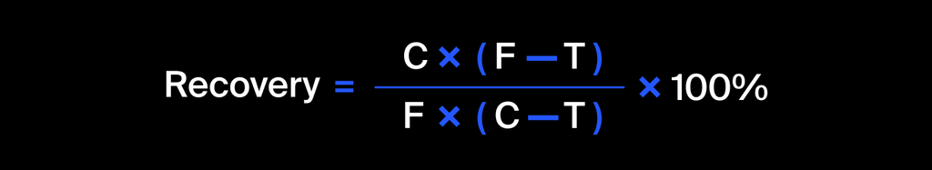

где:

- C — доля золота в концентрате после флотации/очистки;
- F — доля золота в сырье/концентрате до флотации/очистки;
- T — доля золота в отвальных хвостах после флотации/очистки.

Напишем функцию для расчета:

```python
# Считаем по формуле значение rougher.output.recovery и записываем в отдельный столбец
df_train['rougher.output.recovery_check'] = (
    (df_train['rougher.output.concentrate_au']*(df_train['rougher.input.feed_au'] - df_train['rougher.output.tail_au']))/
    (df_train['rougher.input.feed_au']*(df_train['rougher.output.concentrate_au'] - df_train['rougher.output.tail_au']))
    *100)

# смотрим результаты
print()
print(color.BLUE + color.BOLD + 'Табличное и проверочное расчетное rougher.output.recovery:' + color.END)
display(df_train[['rougher.output.recovery', 'rougher.output.recovery_check']])
print()
print(color.BLUE + color.BOLD + 'Средняя абсолютная ошибка MAE для rougher.output.recovery:' + color.END,
      mean_absolute_error(df_train['rougher.output.recovery_check'], df_train['rougher.output.recovery'])
     )
```

```
Табличное и проверочное расчетное rougher.output.recovery:
```

| date | rougher.output.recovery | rougher.output.recovery_check |
| --- | --- | --- |
| 2016-01-15 00:00:00 | 87.11 | 87.11 |
| 2016-01-15 01:00:00 | 86.84 | 86.84 |
| 2016-01-15 02:00:00 | 86.84 | 86.84 |
| 2016-01-15 03:00:00 | 87.23 | 87.23 |
| 2016-01-15 04:00:00 | 86.69 | 86.69 |
| ... | ... | ... |
| 2018-08-18 06:59:59 | 89.57 | 89.57 |
| 2018-08-18 07:59:59 | 87.72 | 87.72 |
| 2018-08-18 08:59:59 | 88.89 | 88.89 |
| 2018-08-18 09:59:59 | 89.86 | 89.86 |
| 2018-08-18 10:59:59 | 89.51 | 89.51 |

14149 rows × 2 columns

```
Средняя абсолютная ошибка MAE для rougher.output.recovery: 3.9864044e-06
```

**Вывод:** Проверка расчетов подтвердила корректность вычисления rougher.output.recovery. Полученное значение MAE пренебрежительно мало и отражает, возможно, нюансы вычсилений/округлений, но не ошибки в расчетах.

Оценим визуально динамику основных расчетных параметров и влияющих величин:

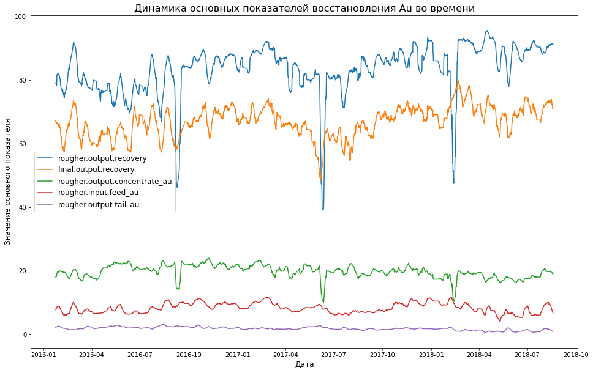

```python
# функция расчета скользящего среднего
def filter_data(df, window):
    # для каждого столбца применяем скользящее среднее
    for column in df.columns.values:
        df[column] = df[column].rolling(window).mean()
    return df

# строим графики значений. берем скользящее среднее, чтобы убрать шумы
plt.figure(figsize=(16,10))
plt.plot(filter_data(df_full[['rougher.output.recovery']], 180), label='rougher.output.recovery')
plt.plot(filter_data(df_full[['final.output.recovery']], 180), label='final.output.recovery')
plt.plot(filter_data(df_full[['rougher.output.concentrate_au']], 180), label='rougher.output.concentrate_au')
plt.plot(filter_data(df_full[['rougher.input.feed_au']], 180), label='rougher.input.feed_au')
plt.plot(filter_data(df_full[['rougher.output.tail_au']], 180), label='rougher.output.tail_au')
plt.xlabel('Дата', fontsize=12)
plt.ylabel('Значение основного показателя', fontsize=12)
plt.title('Динамика основных показателей восстановления Au во времени', fontsize=16)
plt.legend(fontsize=12)
plt.show()
```

Видим, что параметр восстановления на этапе флотации сильно коррелирует с концентрацией Au на выходе флотации. При этом финальный расчетный параметр восстановления 'final.output.recovery' имеет несколько иные значения и более стабилен.

### Предобработка данных

Мы уже поработали над имеющимися данными, убрали пропуски. Но перед тем как приступить к обучению моделей, необходимо выполнить следующие подготовительные моменты:

- Целевые признаки `rougher.output.recovery` и `final.output.recovery` присутствуют в обучающей и изначальной выборке, но отсутствуют в тестовой. Чтобы была возможность оценить качество готовой модели на тесте, нам необходимо восстановить таргеты в тестовой выборке по полным данным.
- В обучающей выборке присутствуют признаки (помимо таргетов), которых нет в тестовой выборке. Необходимо исключить их при обучении модели, т.к. они являются расчетными/измеренными постфактум, а значит не могут быть фичами для обучения.
- В обучающей выборке представлены параметры, значения которых могут отличаться друг от друга на несколько порядков. Необходимо масштабировать признаки, чтобы улучшить качетство предсказаний некоторых моделей.
- Мы будем решать задачу регрессии, т.е. предсказывать значение целевого признака. Для оценки качества модели нам предлагается использовать sMAPE (англ. Symmetric Mean Absolute Percentage Error, «симметричное среднее абсолютное процентное отклонение»). Эта метрика очень похожа на MAE, но выражает процентное отклонение от среднего. Модели будем оптимизировать по MAE (или RMSE, если модель не поддерживает иное).

#### Внедрение таргетов из общей выборки в тестовую

Т.к. тестовая выборка получена из исходных данных, применим `join`, чтобы подгрузить таргеты по индексам.

```python
df_test = df_test.join(df_full.loc[df_test.index][['final.output.recovery','rougher.output.recovery']])
df_test.info()
```

```
<class 'pandas.core.frame.DataFrame'>
DatetimeIndex: 5290 entries, 2016-09-01 00:59:59 to 2017-12-31 23:59:59
Data columns (total 54 columns):
 #   Column                                      Non-Null Count  Dtype
---  ------                                      --------------  -----
 0   primary_cleaner.input.sulfate               5290 non-null   float32
 1   primary_cleaner.input.depressant            5290 non-null   float32
 2   primary_cleaner.input.feed_size             5290 non-null   float32
 3   primary_cleaner.input.xanthate              5290 non-null   float32
 4   primary_cleaner.state.floatbank8_a_air      5290 non-null   float32
 5   primary_cleaner.state.floatbank8_a_level    5290 non-null   float32
 6   primary_cleaner.state.floatbank8_b_air      5290 non-null   float32
 7   primary_cleaner.state.floatbank8_b_level    5290 non-null   float32
 8   primary_cleaner.state.floatbank8_c_air      5290 non-null   float32
 9   primary_cleaner.state.floatbank8_c_level    5290 non-null   float32
```

[output cut: 46 more lines]

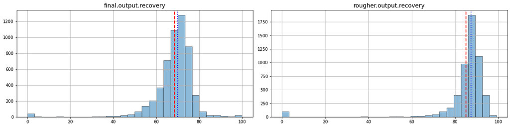

```python
# Смотрим визуальной распределение целевого признака
show_hist(df_test[['final.output.recovery','rougher.output.recovery']], 2, 4)
```

Мы успешно добавили целевые признаки в тестовую выборку. Теперь разделим ее на фичи и таргеты.

```python
# Выделяем фичи и таргеты
features_test = df_test.reset_index().drop(['rougher.output.recovery', 'final.output.recovery', 'date'], axis=1)
target_test = (df_test.reset_index().drop(['date'], axis=1)
               [['rougher.output.recovery', 'final.output.recovery']])

# Смотрим результат
display(features_test.head())
display(target_test.head())
```

|  | primary_cleaner.input.sulfate | primary_cleaner.input.depressant | primary_cleaner.input.feed_size | primary_cleaner.input.xanthate | primary_cleaner.state.floatbank8_a_air | primary_cleaner.state.floatbank8_a_level | primary_cleaner.state.floatbank8_b_air | primary_cleaner.state.floatbank8_b_level | primary_cleaner.state.floatbank8_c_air | primary_cleaner.state.floatbank8_c_level | primary_cleaner.state.floatbank8_d_air | primary_cleaner.state.floatbank8_d_level | rougher.input.feed_ag | rougher.input.feed_pb | rougher.input.feed_rate | rougher.input.feed_size | rougher.input.feed_sol | rougher.input.feed_au | rougher.input.floatbank10_sulfate | rougher.input.floatbank10_xanthate | rougher.input.floatbank11_sulfate | rougher.input.floatbank11_xanthate | rougher.state.floatbank10_a_air | rougher.state.floatbank10_a_level | rougher.state.floatbank10_b_air | ... | rougher.state.floatbank10_c_level | rougher.state.floatbank10_d_air | rougher.state.floatbank10_d_level | … |
| --- | --- | --- | --- | --- | --- | --- | --- | --- | --- | --- | --- | --- | --- | --- | --- | --- | --- | --- | --- | --- | --- | --- | --- | --- | --- | --- | --- | --- | --- | --- |
| 0 | 210.80 | 14.99 | 8.08 | 1.01 | 1398.98 | -500.23 | 1399.14 | -499.92 | 1400.10 | -500.70 | 1399.00 | -499.49 | 13.13 | 5.64 | 489.79 | 62.71 | 42.02 | 12.08 | 16.92 | 6.15 | 16.87 | 6.15 | 1001.85 | -350.30 | 1249.74 | ... | -399.40 | 1198.29 | -399.49 | … |
| 1 | 215.39 | 14.99 | 8.08 | 0.99 | 1398.78 | -500.06 | 1398.06 | -499.78 | 1396.15 | -499.24 | 1399.51 | -500.42 | 13.04 | 5.53 | 490.10 | 61.96 | 41.19 | 11.92 | 17.00 | 6.00 | 17.00 | 6.00 | 998.69 | -350.43 | 1248.40 | ... | -399.63 | 1200.51 | -399.94 | … |
| 2 | 215.26 | 12.88 | 7.79 | 1.00 | 1398.49 | -500.87 | 1398.86 | -499.76 | 1398.08 | -502.15 | 1399.50 | -499.72 | 13.14 | 5.43 | 489.62 | 66.90 | 42.55 | 12.09 | 16.99 | 5.85 | 16.98 | 5.85 | 998.52 | -349.78 | 1247.44 | ... | -401.07 | 1199.77 | -400.79 | … |
| 3 | 215.34 | 12.01 | 7.64 | 0.86 | 1399.62 | -498.86 | 1397.44 | -499.21 | 1400.13 | -498.36 | 1401.07 | -501.04 | 12.40 | 5.11 | 476.62 | 59.87 | 41.06 | 12.18 | 16.53 | 5.80 | 16.52 | 5.80 | 1000.28 | -350.17 | 1251.32 | ... | -399.75 | 1199.40 | -397.50 | … |
| 4 | 199.10 | 10.68 | 7.53 | 0.81 | 1401.27 | -500.81 | 1398.13 | -499.50 | 1402.17 | -500.81 | 1399.48 | -499.37 | 11.33 | 4.77 | 488.25 | 63.32 | 41.27 | 11.29 | 13.61 | 5.74 | 13.65 | 5.74 | 996.54 | -350.56 | 1304.66 | ... | -399.05 | 1248.70 | -400.88 | … |

5 rows × 52 columns

|  | rougher.output.recovery | final.output.recovery |
| --- | --- | --- |
| 0 | 89.99 | 70.27 |
| 1 | 88.09 | 68.91 |
| 2 | 88.41 | 68.14 |
| 3 | 87.36 | 67.78 |
| 4 | 83.24 | 61.47 |

Успех. Теперь у нас есть корректная тестовая выборка, а так же отдельно фичи и тагеты теста.

#### Корректировка обучающей выборки

```python
# Т.к. у нас одна генеральная совокупность, и часть признаков общие -
# просто отбираем в train те колонки, которые есть в test
df_train_cut = df_train[df_test.columns].reset_index()

# Выделяем фичи и таргеты
features_train = df_train_cut.drop(['rougher.output.recovery', 'final.output.recovery', 'date'], axis=1)
target_train = df_train_cut[['rougher.output.recovery', 'final.output.recovery']]

# Смотрим результат
display(features_train.head())
display(target_train.head())
```

|  | primary_cleaner.input.sulfate | primary_cleaner.input.depressant | primary_cleaner.input.feed_size | primary_cleaner.input.xanthate | primary_cleaner.state.floatbank8_a_air | primary_cleaner.state.floatbank8_a_level | primary_cleaner.state.floatbank8_b_air | primary_cleaner.state.floatbank8_b_level | primary_cleaner.state.floatbank8_c_air | primary_cleaner.state.floatbank8_c_level | primary_cleaner.state.floatbank8_d_air | primary_cleaner.state.floatbank8_d_level | rougher.input.feed_ag | rougher.input.feed_pb | rougher.input.feed_rate | rougher.input.feed_size | rougher.input.feed_sol | rougher.input.feed_au | rougher.input.floatbank10_sulfate | rougher.input.floatbank10_xanthate | rougher.input.floatbank11_sulfate | rougher.input.floatbank11_xanthate | rougher.state.floatbank10_a_air | rougher.state.floatbank10_a_level | rougher.state.floatbank10_b_air | ... | rougher.state.floatbank10_c_level | rougher.state.floatbank10_d_air | rougher.state.floatbank10_d_level | … |
| --- | --- | --- | --- | --- | --- | --- | --- | --- | --- | --- | --- | --- | --- | --- | --- | --- | --- | --- | --- | --- | --- | --- | --- | --- | --- | --- | --- | --- | --- | --- |
| 0 | 127.09 | 10.13 | 7.25 | 0.99 | 1549.78 | -498.91 | 1551.43 | -516.40 | 1549.87 | -498.67 | 1554.37 | -493.43 | 6.10 | 2.28 | 523.55 | 55.49 | 36.81 | 6.49 | 11.99 | 6.01 | 11.84 | 6.01 | 999.71 | -404.07 | 1603.01 | ... | -442.20 | 1598.94 | -451.29 | … |
| 1 | 125.63 | 10.30 | 7.25 | 1.00 | 1576.17 | -500.90 | 1575.95 | -499.87 | 1575.99 | -499.32 | 1574.48 | -498.93 | 6.16 | 2.27 | 525.29 | 57.28 | 35.75 | 6.48 | 11.97 | 6.01 | 12.00 | 6.01 | 1000.29 | -400.07 | 1600.75 | ... | -449.83 | 1600.53 | -449.95 | … |
| 2 | 123.82 | 11.32 | 7.25 | 0.99 | 1601.56 | -500.00 | 1600.39 | -500.61 | 1602.00 | -500.87 | 1599.54 | -499.83 | 6.12 | 2.16 | 530.03 | 57.51 | 35.97 | 6.36 | 11.92 | 6.20 | 11.92 | 6.20 | 999.72 | -400.07 | 1599.34 | ... | -449.95 | 1599.85 | -449.95 | … |
| 3 | 122.27 | 11.32 | 7.25 | 1.00 | 1599.97 | -500.95 | 1600.66 | -499.68 | 1600.30 | -500.73 | 1600.45 | -500.05 | 6.04 | 2.04 | 542.59 | 57.79 | 36.86 | 6.12 | 11.63 | 6.20 | 11.69 | 6.20 | 999.81 | -400.20 | 1600.06 | ... | -449.91 | 1597.73 | -450.13 | … |
| 4 | 117.99 | 11.91 | 7.25 | 1.01 | 1601.34 | -498.98 | 1601.44 | -500.32 | 1599.58 | -500.89 | 1602.65 | -500.59 | 6.06 | 1.79 | 540.53 | 56.05 | 34.35 | 5.66 | 10.96 | 6.20 | 10.96 | 6.19 | 999.68 | -399.75 | 1600.21 | ... | -450.03 | 1599.76 | -449.91 | … |

5 rows × 52 columns

|  | rougher.output.recovery | final.output.recovery |
| --- | --- | --- |
| 0 | 87.11 | 70.54 |
| 1 | 86.84 | 69.27 |
| 2 | 86.84 | 68.12 |
| 3 | 87.23 | 68.35 |
| 4 | 86.69 | 66.93 |

Изменение обучающей выборки успешно. Данные обучающей выборки разделены на фичи и таргеты. Дополнително создадим вариант тестовой выборки с масштабированными признаками.

#### Масштабирование признаков обучающей выборки

В столбцах находятся данные разного масштаба, для корректного обучения некоторых моделей будет полезно привести признаки к одному масштабу. Для этого будем использовать функцию `StandardScaler` из библиотеки `sklearn`:

```python
# отбираем все чсиловые колонки
numeric = features_train.select_dtypes(include='number').columns.to_list()

# обучаем StandardScaler
scaler = StandardScaler()
scaler.fit(features_train[numeric])

# Создаем копии train и test, чтобы иметь возможность обучаться как на изначальных, так и на масштабированных признаках
features_train_scale = features_train.copy()
features_test_scale = features_test.copy()

# Масштабируем признаки
features_train_scale[numeric] = scaler.transform(features_train[numeric])
features_test_scale[numeric] = scaler.transform(features_test[numeric])
```

```python
# смотрим результат
print()
print(color.BLUE + color.BOLD + 'Данные features_train_scale' + color.END)
display(features_train_scale.sample(5))
print()
print(color.BLUE + color.BOLD + 'Данные features_test_scale' + color.END)
display(features_test_scale.sample(5))
```

```
Данные features_train_scale
```

|  | primary_cleaner.input.sulfate | primary_cleaner.input.depressant | primary_cleaner.input.feed_size | primary_cleaner.input.xanthate | primary_cleaner.state.floatbank8_a_air | primary_cleaner.state.floatbank8_a_level | primary_cleaner.state.floatbank8_b_air | primary_cleaner.state.floatbank8_b_level | primary_cleaner.state.floatbank8_c_air | primary_cleaner.state.floatbank8_c_level | primary_cleaner.state.floatbank8_d_air | primary_cleaner.state.floatbank8_d_level | rougher.input.feed_ag | rougher.input.feed_pb | rougher.input.feed_rate | rougher.input.feed_size | rougher.input.feed_sol | rougher.input.feed_au | rougher.input.floatbank10_sulfate | rougher.input.floatbank10_xanthate | rougher.input.floatbank11_sulfate | rougher.input.floatbank11_xanthate | rougher.state.floatbank10_a_air | rougher.state.floatbank10_a_level | rougher.state.floatbank10_b_air | ... | rougher.state.floatbank10_c_level | rougher.state.floatbank10_d_air | rougher.state.floatbank10_d_level | … |
| --- | --- | --- | --- | --- | --- | --- | --- | --- | --- | --- | --- | --- | --- | --- | --- | --- | --- | --- | --- | --- | --- | --- | --- | --- | --- | --- | --- | --- | --- | --- |
| 9251 | 1.30 | -1.15 | -0.33 | -0.45 | -0.82 | -0.31 | -0.81 | -0.32 | -0.74 | -0.28 | -0.12 | -0.31 | -0.41 | 0.69 | 0.02 | -0.38 | 0.31 | 0.15 | 1.89 | 0.48 | 1.75 | 0.47 | -0.70 | 0.74 | -0.08 | ... | -0.63 | -0.03 | -0.60 | … |
| 2208 | -1.26 | 1.23 | -0.04 | 0.79 | -0.86 | -0.27 | -0.83 | -0.28 | -0.80 | -0.21 | 3.08 | -0.36 | -1.10 | -0.55 | -1.22 | -0.68 | -4.77 | -0.91 | 0.11 | -0.43 | 0.19 | -0.33 | -0.74 | -0.32 | -0.12 | ... | -0.66 | -0.04 | -0.62 | … |
| 10603 | 1.71 | 0.93 | 0.45 | 1.28 | 0.74 | -0.32 | 0.68 | -0.35 | 0.68 | -0.30 | 0.56 | -0.37 | 1.07 | 0.81 | 1.22 | 0.62 | 1.03 | 0.72 | 0.39 | 0.63 | 0.44 | 0.60 | 1.61 | 0.74 | -1.75 | ... | -0.62 | -1.71 | -0.64 | … |
| 11541 | 0.64 | 0.93 | 0.14 | -1.02 | -0.05 | -0.30 | -0.07 | -0.34 | -0.05 | -0.27 | 0.21 | -0.36 | 0.90 | 0.46 | -0.71 | -0.45 | 0.65 | 0.64 | -0.89 | 0.95 | -0.68 | 0.88 | 1.05 | 0.74 | -1.20 | ... | -0.60 | -1.21 | -0.63 | … |
| 12195 | 1.82 | 0.95 | -1.01 | 0.03 | 0.73 | -0.29 | 0.71 | -0.33 | 0.69 | -0.27 | 0.57 | -0.36 | 1.57 | 1.52 | 0.69 | 0.85 | 1.36 | 1.91 | 1.03 | 1.04 | 1.00 | 0.97 | 0.46 | 0.74 | -0.09 | ... | -0.64 | -0.04 | -0.61 | … |

5 rows × 52 columns

```
Данные features_test_scale
```

|  | primary_cleaner.input.sulfate | primary_cleaner.input.depressant | primary_cleaner.input.feed_size | primary_cleaner.input.xanthate | primary_cleaner.state.floatbank8_a_air | primary_cleaner.state.floatbank8_a_level | primary_cleaner.state.floatbank8_b_air | primary_cleaner.state.floatbank8_b_level | primary_cleaner.state.floatbank8_c_air | primary_cleaner.state.floatbank8_c_level | primary_cleaner.state.floatbank8_d_air | primary_cleaner.state.floatbank8_d_level | rougher.input.feed_ag | rougher.input.feed_pb | rougher.input.feed_rate | rougher.input.feed_size | rougher.input.feed_sol | rougher.input.feed_au | rougher.input.floatbank10_sulfate | rougher.input.floatbank10_xanthate | rougher.input.floatbank11_sulfate | rougher.input.floatbank11_xanthate | rougher.state.floatbank10_a_air | rougher.state.floatbank10_a_level | rougher.state.floatbank10_b_air | ... | rougher.state.floatbank10_c_level | rougher.state.floatbank10_d_air | rougher.state.floatbank10_d_level | … |
| --- | --- | --- | --- | --- | --- | --- | --- | --- | --- | --- | --- | --- | --- | --- | --- | --- | --- | --- | --- | --- | --- | --- | --- | --- | --- | --- | --- | --- | --- | --- |
| 477 | -1.85 | -1.04 | -1.66 | -0.73 | -0.04 | -0.33 | -0.08 | -0.32 | -0.07 | -0.27 | 0.21 | -0.34 | 0.56 | -0.05 | -0.71 | -0.72 | -0.16 | 0.98 | -0.98 | 0.55 | -0.76 | 0.52 | -0.73 | -1.39 | -0.65 | ... | -0.65 | -0.05 | -0.63 | … |
| 3294 | 0.99 | -0.71 | -0.67 | 2.46 | -0.54 | -0.33 | -0.06 | -0.30 | -0.08 | -0.29 | 0.20 | -0.34 | -1.33 | -0.29 | 1.04 | -0.09 | 1.58 | -0.51 | 1.89 | 0.76 | 1.75 | 0.72 | -0.69 | 0.74 | 0.47 | ... | -0.61 | 0.45 | -0.64 | … |
| 2993 | -0.28 | -0.10 | -0.80 | 1.09 | -1.64 | -0.32 | -1.62 | -0.33 | -1.58 | -0.31 | -0.51 | -0.35 | -1.39 | -0.04 | 0.74 | -0.17 | 0.41 | -0.27 | 1.59 | 0.77 | 1.48 | 0.72 | -0.71 | 0.74 | -0.12 | ... | -0.63 | -0.05 | -0.62 | … |
| 2817 | 0.33 | -0.54 | -1.06 | 0.44 | -2.44 | -0.32 | -2.37 | -0.32 | -2.30 | -0.29 | -0.87 | -0.35 | -1.52 | -0.90 | 0.45 | -0.18 | -0.34 | -0.68 | 1.59 | -0.43 | 1.48 | -0.34 | -0.72 | 0.74 | -0.12 | ... | -0.63 | -0.08 | -0.62 | … |
| 2847 | 0.34 | -0.40 | -0.64 | 0.44 | -2.43 | -0.31 | -2.33 | -0.29 | -2.31 | -0.19 | -0.87 | -0.33 | -1.14 | -0.40 | 0.51 | -0.23 | 0.84 | -0.59 | 1.59 | -0.14 | 1.48 | -0.08 | -0.71 | 0.74 | -0.10 | ... | -0.62 | -0.06 | -0.57 | … |

5 rows × 52 columns

Скалирование признаков успешно. Теперь мы можем использовать для обучения как скалированные, так и изначальные признаки.

## Анализ данных

### Оценка изменения концентрации металлов (Au, Ag, Pb) на различных этапах очистки

```python
# Создадим функцию, которая строит гистограммы по выбранному параметру для различных этапов
def show_met_concentate(df, col1, col2, col3, title):

    print() # задаем отступ 1 строку

    plt.figure(figsize=(16,7))
    # Строим гистограмму параметра col1
    plt.hist(df[col1], bins=50, color='red', edgecolor='black', alpha=.5, label = col1, density = False)
    # Отображаем среднее и медианное значение col1
    plt.axvline(df[col1].mean(), color='red', linestyle='dashed', linewidth=2,
                label='Средний показатель {}'.format(col1))
    plt.axvline(df[col1].median(), color='red', linestyle='dotted', linewidth=2,
                label='Медиианный показатель {}'.format(col1))

    # Строим гистограмму параметра col2
    plt.hist(df[col2], bins=50, color='dodgerblue', edgecolor='black', alpha=.5, label = col2, density = False)
    # Отображаем среднее и медианное значение col2
    plt.axvline(df[col2].mean(), color='blue', linestyle='dashed', linewidth=2,
                label='Средний показатель {}'.format(col2))
    plt.axvline(df[col2].median(), color='blue', linestyle='dotted', linewidth=2,
                label='Медиианный показатель {}'.format(col2))

   # Строим гистограмму параметра col3
    plt.hist(df[col3], bins=50, color='green', edgecolor='black', alpha=.5, label = col3, density = False)
    # Отображаем среднее и медианное значение col3
    plt.axvline(df[col3].mean(), color='green', linestyle='dashed', linewidth=2,
                label='Средний показатель {}'.format(col3))
    plt.axvline(df[col3].median(), color='green', linestyle='dotted', linewidth=2,
                label='Медиианный показатель {}'.format(col3))

    plt.xlabel('Показатель исследуемого значения')
    plt.ylabel('Количество значений с таким показателем')
    plt.title(title, fontsize=16)
    plt.legend()
    plt.show()
```

#### Оценка изменения концентрации (Au) на различных этапах очистки

**Оценка изменения концентрации (Au) в продукте на различных этапах очистки**

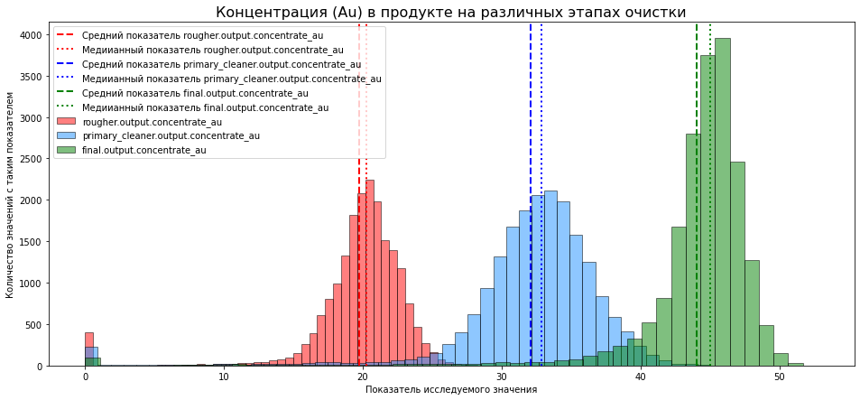

```python
# Выводим распределения параметра с помощью написанной выше функции
show_met_concentate(
               df_full,
              'rougher.output.concentrate_au',
              'primary_cleaner.output.concentrate_au',
              'final.output.concentrate_au',
              'Концентрация (Au) в продукте на различных этапах очистки'
                    )
```

**Оценка изменения концентрации (Au) в отвальных хвостах на различных этапах очистки**

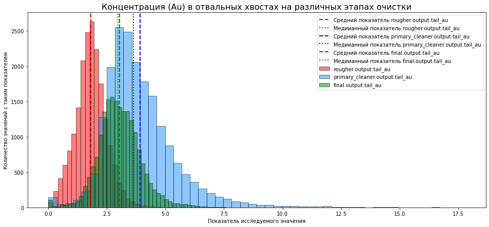

```python
# Выводим распределения параметра с помощью написанной выше функции
show_met_concentate(
               df_full,
              'rougher.output.tail_au',
              'primary_cleaner.output.tail_au',
              'final.output.tail_au',
              'Концентрация (Au) в отвальных хвостах на различных этапах очистки'
                    )
```

**Наблюдения:**

- Количество Au, содержащееся в породе после каждой из степеней очистки возрастает. Это логично.
- Количество Au, содержащееся в породе в отвальных хвостах относительно невелико.
- Больше всего Au отсеивается в отвальных хвостах на 1 этапе очистки. Менее всего - на этапе флотации. Но процент небольшой.

#### Оценка изменения концентрации (Ag) на различных этапах очистки

**Оценка изменения концентрации (Ag) в продукте на различных этапах очистки**

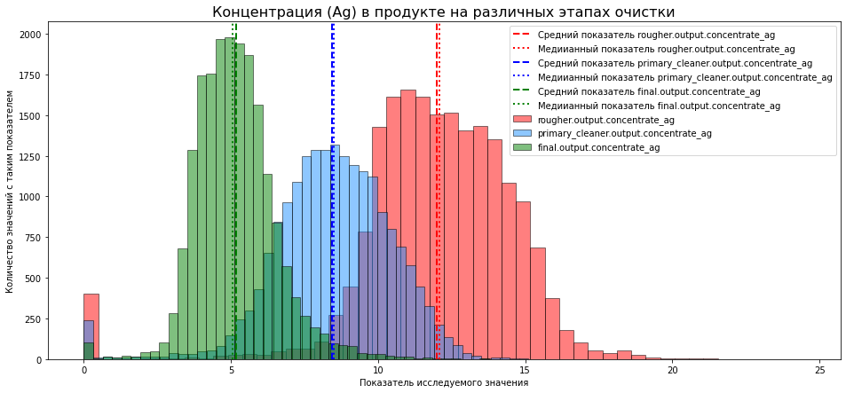

```python
# Выводим распределения параметра с помощью написанной выше функции
show_met_concentate(
               df_full,
              'rougher.output.concentrate_ag',
              'primary_cleaner.output.concentrate_ag',
              'final.output.concentrate_ag',
              'Концентрация (Ag) в продукте на различных этапах очистки'
                    )
```

**Оценка изменения концентрации (Ag) в отвальных хвостах на различных этапах очистки**

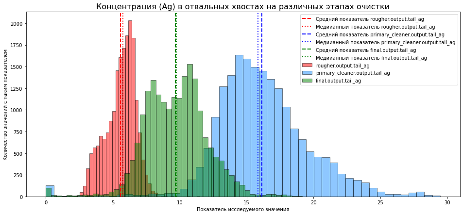

```python
# Выводим распределения параметра с помощью написанной выше функции
show_met_concentate(
               df_full,
              'rougher.output.tail_ag',
              'primary_cleaner.output.tail_ag',
              'final.output.tail_ag',
              'Концентрация (Ag) в отвальных хвостах на различных этапах очистки'
                    )
```

#### Оценка изменения концентрации (Pb) на различных этапах очистки

**Оценка изменения концентрации (Pb) в продукте на различных этапах очистки**

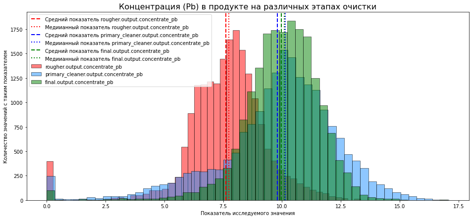

```python
# Выводим распределения параметра с помощью написанной выше функции
show_met_concentate(
               df_full,
              'rougher.output.concentrate_pb',
              'primary_cleaner.output.concentrate_pb',
              'final.output.concentrate_pb',
              'Концентрация (Pb) в продукте на различных этапах очистки'
                    )
```

**Оценка изменения концентрации (Pb) в отвальных хвостах на различных этапах очистки**

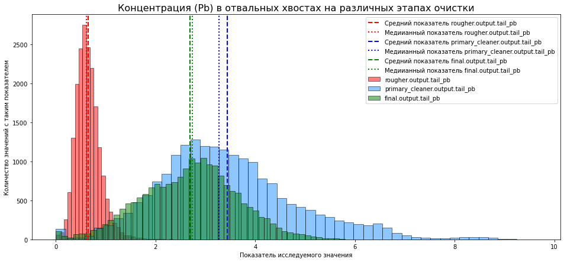

```python
# Выводим распределения параметра с помощью написанной выше функции
show_met_concentate(
               df_full,
              'rougher.output.tail_pb',
              'primary_cleaner.output.tail_pb',
              'final.output.tail_pb',
              'Концентрация (Pb) в отвальных хвостах на различных этапах очистки'
                    )
```

### Распределение размера гранул сырья на обучающей и тестовой выборках

По условию ТЗ нам необходимо изучить размер гранул сырья в обучающей и тестовой выборке. Нам доступны данные о размере гранул на входе проесса флотации `rougher.input.feed_size` и на входе первого этапа очистки `primary_cleaner.input.feed_size`. Посмотрим распределения этих величин в тестовой и обучающей выборках.

```python
# Функция строит гистограммы. На вход принимает датасет и кол-во столбцов в subplot
def show_hist_kde(df, columns, k_height):
    # задаем размер графика
    plt.figure(figsize=(17, df.columns.nunique()*k_height))
    # перебираем все параметры-колонки
    for i, col in enumerate(df.columns):
        # для наглядности выводим гистограммы в subplot. Параметр позиции вывода берем +1, т.к. индексы в i идут с 0
        ax=plt.subplot(int(df.columns.nunique()/columns)+1, columns, i+1)

        # Строим гистограмму параметра col на обучающей выборке
        plt.hist(df_train[col], bins=50, color='red', edgecolor='black', alpha=.4, label = 'df_train', density = True)
        # Отображаем среднее и медианное значение col на обучающей выборке
        plt.axvline(df_train[col].mean(), color='red', linestyle='dashed', linewidth=3,
                    label='train')

        # Строим гистограмму параметра col на тестовой выборке
        plt.hist(df_test[col], bins=50, color='dodgerblue', edgecolor='black', alpha=.4, label = 'df_test', density = True)
        # Отображаем среднее и медианное значение col на тестовой выборке
        plt.axvline(df_test[col].mean(), color='blue', linestyle='dashed', linewidth=2,
                    label='test')



        plt.legend()
        plt.xlabel('')
        plt.ylabel('')
        plt.title(f'{col}', fontsize = 14)

    plt.tight_layout()
    plt.show()
```

```python
#show_hist_kde(df_test, 3, 1.4)
```

```python
# Создадим функцию, которая строит гистограммы по выбранному параметру
# для обучающей и тестовой выборок
def show_feed_size(col, title):

    plt.figure(figsize=(16,7))
    # Строим гистограмму параметра col на обучающей выборке
    plt.hist(df_train[col], bins=50, color='red', edgecolor='black', alpha=.5, label = 'df_train', density = True)
    # Отображаем среднее и медианное значение col на обучающей выборке
    plt.axvline(df_train[col].mean(), color='red', linestyle='dashed', linewidth=3,
                label='Средний показатель {} на train'.format(col))
    plt.axvline(df_train[col].median(), color='red', linestyle='dotted', linewidth=3,
                label='Медиианный показатель {} на train'.format(col))

    # Строим гистограмму параметра col на тестовой выборке
    plt.hist(df_test[col], bins=50, color='dodgerblue', edgecolor='black', alpha=.5, label = 'df_test', density = True)
    # Отображаем среднее и медианное значение col на тестовой выборке
    plt.axvline(df_test[col].mean(), color='blue', linestyle='dashed', linewidth=2,
                label='Средний показатель {} на test'.format(col))
    plt.axvline(df_test[col].median(), color='blue', linestyle='dotted', linewidth=2,
                label='Медиианный показатель {} на test'.format(col))

    plt.xlabel('Показатель исследуемого значения', fontsize=12)
    plt.ylabel('Количество значений с таким показателем', fontsize=12)
    plt.title(title, fontsize=16)
    plt.legend(fontsize=12)
    plt.show()
```

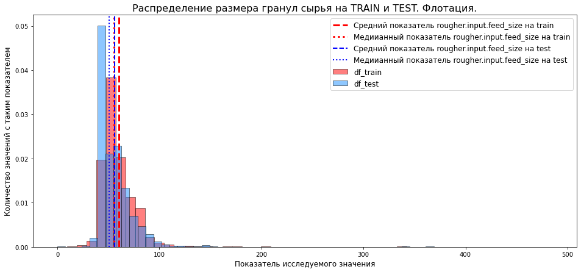

```python
show_feed_size('rougher.input.feed_size', 'Распределение размера гранул сырья на TRAIN и TEST. Флотация.')
```

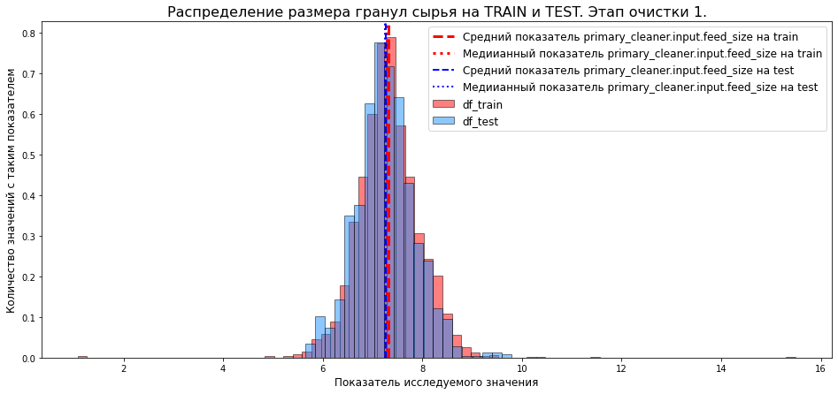

```python
show_feed_size('primary_cleaner.input.feed_size', 'Распределение размера гранул сырья на TRAIN и TEST. Этап очистки 1.')
```

Как мы видим, значения размера гранул очень похожи в тестовой и обучающей выборках. Среднее значение и медиана практически совпадают. На фходе этапа флотации есть большие выбросы, но к этапу первой очистки мы получаем весьма равномерное нормальное распределение практически без выбросов. Проблем не наблюдается.

### Оценка суммарной концентрации всех веществ на различных этапах очистки

По ТЗ необходимо оценить изменение концентрации всех вешеств суммарно на различных этапах очистки. Нам доступны данные по металлам Au, Ag и Pb, а так же данные по солям Sol. Однако соли - это побочный продукт, который образуется как результат использования реагентов в технологическом процессе офистки. Поэтому мы будем оценивать только суммарное кол-во Au, Ag и Pb.

Для начала сохраним в отдельном датасете суммарные показатели веществ в привязке к этапу.

```python
# сохраняем данные df_train в отдельный датафрейм, с которым будем работать
sum_substance = df_full.copy()

# считаем суммарные показатели концентрации Au, Ag, Pb в продукте по результатам 3-х этапов
sum_substance['rougher.output.concentrate.total'] = (df_full['rougher.output.concentrate_ag'] +
                                                     df_full['rougher.output.concentrate_pb'] +
                                                     df_full['rougher.output.concentrate_au'])
sum_substance['primary_cleaner.output.concentrate.total'] = (df_full['primary_cleaner.output.concentrate_ag'] +
                                                             df_full['primary_cleaner.output.concentrate_pb'] +
                                                             df_full['primary_cleaner.output.concentrate_au'])
sum_substance['final.output.concentrate.total'] = (df_full['final.output.concentrate_ag'] +
                                                   df_full['final.output.concentrate_pb'] +
                                                   df_full['final.output.concentrate_au'])

# считаем суммарные показатели Au, Ag, Pb в отвальных хвостах по результатам 3-х этапов
sum_substance['rougher.output.tail.total'] = (df_full['rougher.output.tail_ag'] +
                                              df_full['rougher.output.tail_pb'] +
                                              df_full['final.output.tail_au'])
sum_substance['primary_cleaner.output.tail.total'] = (df_full['primary_cleaner.output.tail_ag'] +
                                                      df_full['primary_cleaner.output.tail_pb'] +
                                                      df_full['primary_cleaner.output.tail_au'])
sum_substance['final.output.tail.total'] = (df_full['final.output.tail_ag'] +
                                            df_full['final.output.tail_pb'] +
                                            df_full['final.output.tail_au'])

# Оставляем только суммарные значения
sum_substance = sum_substance[['rougher.output.concentrate.total',
                               'primary_cleaner.output.concentrate.total',
                               'final.output.concentrate.total',
                               'rougher.output.tail.total',
                               'primary_cleaner.output.tail.total',
                               'final.output.tail.total'
                              ]]

# Смотрим результат - случайные 5 строк данных
sum_substance.sample(5)
```

| date | rougher.output.concentrate.total | primary_cleaner.output.concentrate.total | final.output.concentrate.total | rougher.output.tail.total | primary_cleaner.output.tail.total | final.output.tail.total |
| --- | --- | --- | --- | --- | --- | --- |
| 2017-04-02 01:59:59 | 38.69 | 48.60 | 60.18 | 9.99 | 13.50 | 14.97 |
| 2016-12-30 16:59:59 | 42.18 | 48.51 | 58.76 | 11.99 | 24.79 | 19.51 |
| 2016-06-14 18:59:59 | 37.62 | 47.18 | 59.91 | 9.27 | 20.32 | 11.65 |
| 2017-05-06 05:59:59 | 42.98 | 53.68 | 61.35 | 10.65 | 24.25 | 16.70 |
| 2016-10-13 06:59:59 | 42.27 | 51.31 | 60.21 | 11.98 | 24.53 | 18.64 |

Данные подготовлены. Теперь посмотрим визуально как изменяется распределение суммарной концетрации веществ на разных этапах.

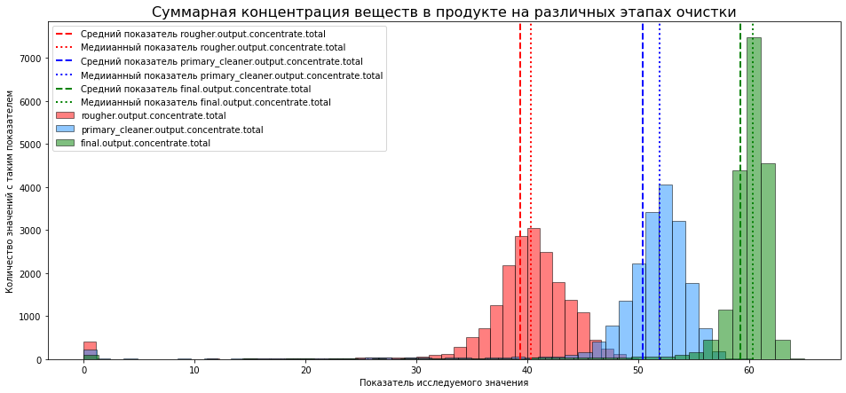

```python
# смотрим концентрацию продукта с помощью написанной ранее функции
show_met_concentate(sum_substance,
                    'rougher.output.concentrate.total',
                    'primary_cleaner.output.concentrate.total',
                    'final.output.concentrate.total',
                    'Суммарная концентрация веществ в продукте на различных этапах очистки'
                   )
```

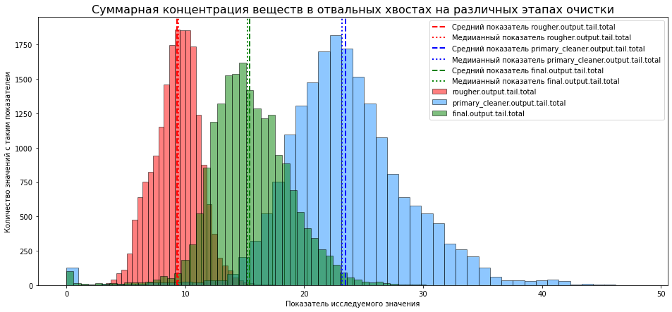

```python
# смотрим концентрацию в отвальных хвостах с помощью написанной ранее функции
show_met_concentate(sum_substance,
                    'rougher.output.tail.total',
                    'primary_cleaner.output.tail.total',
                    'final.output.tail.total',
                    'Суммарная концентрация веществ в отвальных хвостах на различных этапах очистки'
                   )
```

**Выводы:**

- После каждой из степеней очистки суммарная концентрация Au, Ag, Pb равномерно нарастает. Разброс значений параметра становится меньше.
- Суммарное количество Au, Ag, Pb в отвальных хвостах после каждой стадии не линейно. Меньше всего хвосты после флотации, больше всего после первой стадии очистки. Разброс значений суммарной концентрации Au, Ag, Pb в отвальных хвостах после 1 этапа самый большой.
- Наблюдаются небольшие выбросы. Есть некоторый отличимый всплеск около нулевых значений как в основном продукте, так и в отвальных хвостах. Это может быть как следствием рабочего процесса (технологическое обслуживание аппаратов при работающих измерителях), так и следствием обработки неудачно взятой породы.

Происхождение нулевых значений стоит уточнить у заказчика, но веорятно они не являются ошибками. Тактика EDA определяется, конечно, целями решаемой задачи. Т.е. мы должны своей моделью решить проблему заказчика. Если заказчику нужна адекватная модель, которая предсказывает близкие результаты во всех режимах и условиях работы - тогда нельзя удалять нули. Особенно смотреть это по сумме.

Я не разбираюсь в золотодобыче, но могу предположить, что порода может содержать разную концентрацию того или ного металла, в т.ч. и нулевую. Ноль может получиться, если порода истощается (надо менять месторождение). Тогда нули тоже важны. Могут быть сбои оборудования. Если цель Заказчика экспериментально проверить процесс во всех условиях (именно на модели, т.к. эксперимент "на живую" с золотом наверное будет дорогим) - нам нужны максимально полные данные. Например, с помощью такой модели мы сможем посмотреть как влияют на конечный продукт сбои в измерениях (просто отлавливаем такие случаи и проверяем на модели).

```python
print(color.BLUE + color.BOLD + 'Пороговые значения rougher.output.concentrate.total:' + color.END)
sum_substance['rougher.output.concentrate.total'].describe(percentiles = [.01,.02,.03,.04,.05,.95,.96,.97,.98,.99])
```

```
Пороговые значения rougher.output.concentrate.total:
```

```
count   19439.00
mean       39.37
std         6.86
min         0.00
1%          0.00
2%          0.00
3%         24.55
4%         30.87
5%         33.18
50%        40.31
95%        45.40
96%        45.68
97%        46.07
98%        46.69
99%        47.50
max        55.57
Name: rougher.output.concentrate.total, dtype: float64
```

```python
count_reset_values = sum_substance.loc[
    (sum_substance['rougher.output.concentrate.total'] <=
     np.percentile(sum_substance['rougher.output.concentrate.total'], 1)) |
    (sum_substance['rougher.output.concentrate.total'] >=
     np.percentile(sum_substance['rougher.output.concentrate.total'], 99)),
    'rougher.output.concentrate.total'].count()

print('Оставление 98% доверительного интервала rougher.output.concentrate.total == потере {:.2%} данных'
      .format(count_reset_values/len(df_full)))
```

```
Оставление 98% доверительного интервала rougher.output.concentrate.total == потере 3.03% данных
```

## Модель

Мы проанализировали и подготовили все данные. Теперь у нас есть более полные представления о продукте и технологическом процессе. Самое время приступить к обучению моделей.

### Критерий качества - sMAPE

Для оценки качества моделей нам потребуется параметр sMAPE, который вычисляется по приведенной ниже формуле:

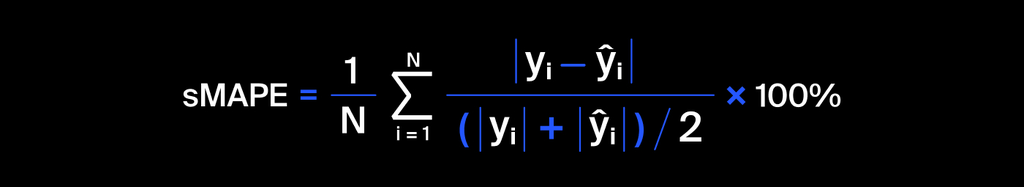

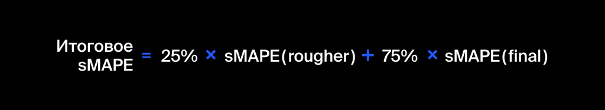

sMAPE (англ. Symmetric Mean Absolute Percentage Error, «симметричное среднее абсолютное процентное отклонение»).

Она похожа на MAE, но выражается не в абсолютных величинах, а в относительных. Она одинаково учитывает масштаб и целевого признака, и предсказания.

```python
# функция расчета sMAPE. У нас есть нулевые значения, поэтому добавим в знаменатель +1e-30 (не повлияет)
def smape_scorer(pred, target):
    smape = (abs((abs(target-pred)/((abs(target)+abs(pred))/2)+1e-30)*100)).mean()
    return (0.25*smape[0] + 0.75*smape[1])
```

Мы будем оценивать модели с помощью кросс-валидации. Для этого будет полезно обернуть нашу метрику в скор, который можно передать функции кросс-валидации.

```python
# создаем свой скор smape_score
smape_score = make_scorer(smape_scorer, greater_is_better = False)
```

### Оценка корреляции признаков

Оценим корреляции признаков (в т.ч. нелинейную) с использование PHIK:

[output not shown]

```
The number of unique values of variable date is large: 14149. Are you sure this is not an interval variable? Analysis for pairs of variables including date can be slow.
```

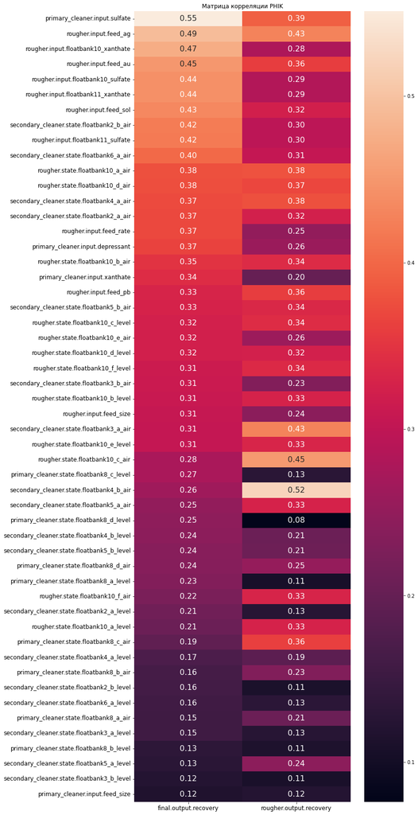

```python
# Определяем индексы нелинейной корреляции и записываем в переменную
phik_overview = df_train_cut.phik_matrix()
# Визуализируем взаимосвязи
plt.figure(figsize=(10,30))
sns.heatmap((phik_overview[['final.output.recovery','rougher.output.recovery']]
            .drop(['rougher.output.recovery', 'final.output.recovery', 'date'], axis=0)
            .sort_values(by=['final.output.recovery','rougher.output.recovery'], ascending=False)),
            annot=True,
            fmt=".2f",
            annot_kws={'fontsize': 16}
           )
plt.xticks(fontsize = 12)
plt.yticks(fontsize = 12)
plt.title('Матрица корреляции PHIK')
plt.show()
```

Как видно из графика, показатель финального восстановления золота **final.output.recovery** сильнее всего связан с параметрами:

- primary_cleaner.input.sulfate (использование сульфатов на входе 1 фазы очистки)
- rougher.input.feed_ag (содержание серебра на входе флотации) По этим параметрам есть сильная корреляция. Так же достаточно сильная корреляция phik есть с параметрами:
- rougher.input.loatbank10_xanthate
- rougher.input.feed_au
- rougher.input.loatbank10_sulfate

Показатель восстановления золота на этапе флотации **rougher.output.recovery** по показаниям phik теснее всего связан с показателем secondary_cleaner.state.floatbank4_b_air. Это немного странно, т.к. это данные приборов второй стадии очистки. Так же сильная связь с параметрами rougher.state.floatbank10_c_air и rougher.input.feed_ag. Это уже показатели процесса флотации. И опять мы видим тесную связь с концентрацией серебра.

Конечно, PHIK не дает нам полной непротиворечивой картины всего процесса на основании данных, но позволяет увидеть некоторые интересные взаимосвязи. Например, зависимость ключевого параметра от концентрации серебра или сульфатов. Посмотрим, как определят взаимосвязи модели.

### Изучение различных моделей

Протестируем несколько моделей, чтобы понять, какая нам лучше подойдет. Из-за ограниченности вычислительных ресурсов мы будем тестировать модели с параметрами, близками к дефолтным. Затем, после выбора лучшей модели, постараемся улучшить ее качество.

#### CatBoost

Тестируем модель CatBoost

```python
%%time
# задаем в словаре параметры CatBoostRegressor
params = {
    'random_state': 42,
    'max_depth': 10,
    'leaf_estimation_method': 'Gradient',
    'bootstrap_type': 'Bernoulli',
    'loss_function': 'MultiRMSE',
    'eval_metric': 'MultiRMSE',
    'verbose': 1000,
    'od_type': 'Iter',
    'od_wait': 200
    }

# инициализируем модель CatBoostRegressor
catb = CatBoostRegressor(**params)

# обучаем модель
catb.fit(features_train, target_train)

# Определяем фолды для CV
folds = KFold(n_splits = 5, shuffle = True, random_state = 42)
# вычисляем средний скор sMAPE на кросс-валидации
score_catb = cross_val_score(catb, features_train_scale, target_train, scoring=smape_score, cv=folds).mean()

# Выводим информацию
print('-'*50)
print('Итоговое значение sMAPE ==', score_catb)
print('-'*50)
```

```
0:	learn: 17.5841453	total: 325ms	remaining: 5m 24s
999:	learn: 5.6770372	total: 2m 37s	remaining: 0us
0:	learn: 17.5982029	total: 159ms	remaining: 2m 38s
999:	learn: 5.4747272	total: 2m 35s	remaining: 0us
0:	learn: 17.3487634	total: 160ms	remaining: 2m 39s
999:	learn: 5.2031984	total: 2m 34s	remaining: 0us
0:	learn: 17.5493635	total: 148ms	remaining: 2m 27s
999:	learn: 5.3892074	total: 2m 34s	remaining: 0us
0:	learn: 17.6710419	total: 159ms	remaining: 2m 39s
999:	learn: 5.3282305	total: 2m 34s	remaining: 0us
0:	learn: 17.7279602	total: 144ms	remaining: 2m 24s
999:	learn: 5.4272486	total: 2m 34s	remaining: 0us
--------------------------------------------------
Итоговое значение sMAPE == -6.990276744214606
--------------------------------------------------
Wall time: 15min 31s
```

#### KNeighbors

Попробуем модель, которая прогнозирует значение целевого признака по значениям ближайших соседей. По условию задачи близкие по времени параметры процессов схожи. Значит данная модель будет применима.

```python
%%time
# задаем в словаре параметры KNeighbors
params = {
    'n_neighbors': 3,
    'weights': 'distance'
    }

# инициализируем модель
knbr = KNeighborsRegressor(**params)

# обучаем модель
knbr.fit(features_train, target_train)

# Определяем фолды для CV
folds = KFold(n_splits = 5, shuffle = True, random_state = 42)
# вычисляем средний скор sMAPE на кросс-валидации
score_knbr = cross_val_score(knbr, features_train, target_train, scoring=smape_score, cv=folds).mean()

# Выводим информацию
print('-'*50)
print('Итоговое значение sMAPE ==', score_knbr)
print('-'*50)
```

```
--------------------------------------------------
Итоговое значение sMAPE == -7.307143407392578
--------------------------------------------------
Wall time: 1.93 s
```

Попробуем обучить модель на масштабированныхфичах. Для модели ближайших соседей уменьшение разброса должно дать хороший результат.

```python
%%time
# задаем в словаре параметры KNeighbors
params = {
    'n_neighbors': 3,
    'weights': 'distance'
    }

# инициализируем модель
knbr = KNeighborsRegressor(**params)

# Определяем фолды для CV
folds = KFold(n_splits = 5, shuffle = True, random_state = 42)
# вычисляем средний скор sMAPE на кросс-валидации
score_knbr = cross_val_score(knbr, features_train_scale, target_train, scoring=smape_score, cv=folds).mean()

# Выводим информацию
print('-'*50)
print('Итоговое значение sMAPE ==', score_knbr)
print('-'*50)
```

```
--------------------------------------------------
Итоговое значение sMAPE == -5.894494906467981
--------------------------------------------------
Wall time: 1.93 s
```

Гипотеза подтвердилась. Великолепный результат.

Однако стоит помнить, что модель KNeighbors фактически не обучается, а изучает тренировочную выборку. Т.е. Модель просто находит значение в нашем случае по 3 ближайшим соседям с минимальными расстояниями. Если процесс консервативный, мало подвежен изменениям (как это говорится в условиях задачи) - такую модель можно использовать.

Если модель разрабатывается с целью так же проводить какие-то эксперименты (эксперименты в реальном техпроцессе с золотом наверное будут стоить оченьдорого), использоваться универсально для разных пород и условия - такая модель вряд ли подойдет. Поэтому не будем придавать большое значение ее текущим результатам.

#### Линейная регрессия

```python
%%time
# инициализируем модель
linereg = LinearRegression()

# Определяем фолды для CV
folds = KFold(n_splits = 5, shuffle = True, random_state = 42)
# вычисляем средний скор sMAPE на кросс-валидации
score_linereg = cross_val_score(linereg, features_train, target_train, scoring=smape_score, cv=folds).mean()

# Выводим информацию
print('-'*50)
print('Итоговое значение sMAPE ==', score_linereg)
print('-'*50)
```

```
--------------------------------------------------
Итоговое значение sMAPE == -9.310529661178588
--------------------------------------------------
Wall time: 91.9 ms
```

Проверим результат на масштабированных фичах:

```python
# инициализируем модель
linereg = LinearRegression()

# Определяем фолды для CV
folds = KFold(n_splits = 5, shuffle = True, random_state = 42)
# вычисляем средний скор sMAPE на кросс-валидации
score_linereg = cross_val_score(linereg, features_train_scale, target_train, scoring=smape_score, cv=folds).mean()

# Выводим информацию
print('-'*50)
print('Итоговое значение sMAPE ==', score_linereg)
print('-'*50)
```

```
--------------------------------------------------
Итоговое значение sMAPE == -9.310531854629517
--------------------------------------------------
```

Масштабирование практически не изменило результат. Модель отработала быстро, но результаты не выдающиеся.

#### Ridge регрессия

Попробуем более сложный вариант линейной регрессии с реальными и масштабированными фичами.

```python
# Определяем фолды для CV
folds = KFold(n_splits = 5, shuffle = True, random_state = 42)

# инициализируем модель
ridge = RidgeCV(scoring=smape_score, cv=folds)

# вычисляем средний скор sMAPE на кросс-валидации
score_ridge = cross_val_score(ridge, features_train, target_train, scoring=smape_score, cv=folds).mean()

# Выводим информацию
print('-'*50)
print('Итоговое значение sMAPE ==', score_ridge)
print('-'*50)
```

```
--------------------------------------------------
Итоговое значение sMAPE == -9.310044622421264
--------------------------------------------------
```

Смотрим результат на масштабированных фичах

```python
# Определяем фолды для CV
folds = KFold(n_splits = 5, shuffle = True, random_state = 42)

# инициализируем модель
ridge = RidgeCV(scoring=smape_score, cv=folds)

# вычисляем средний скор sMAPE на кросс-валидации
score_ridge = cross_val_score(ridge, features_train_scale, target_train, scoring=smape_score, cv=folds).mean()

# Выводим информацию
print('-'*50)
print('Итоговое значение sMAPE ==', score_ridge)
print('-'*50)
```

```
--------------------------------------------------
Итоговое значение sMAPE == -9.306880378723145
--------------------------------------------------
```

Результаты практически соответствуют обычной линейной регрессии.

#### XGBoost

Тестируем еще 1 градиентный бустинг XGBoost

```python
%%time
# задаем в словаре параметры XGBoost
params = {
    'objective': 'reg:squarederror',
    'random_state': 42,
    'booster': 'gbtree',
    'max_depth': 10
    }

# Инициализируем модель. MultiOutputRegressor нужен, т.к. у нас два таргета в 1 модели
estimator = XGBRegressor(**params)
xgb = MultiOutputRegressor(estimator=estimator)

# обучаем модель
xgb.fit(features_train, target_train)

# Определяем фолды для CV
folds = KFold(n_splits = 5, shuffle = True, random_state = 42)
# вычисляем средний скор sMAPE на кросс-валидации
score_xgb = cross_val_score(xgb, features_train, target_train, scoring=smape_score, cv=folds).mean()

# Выводим информацию
print('-'*50)
print('Итоговое значение sMAPE ==', score_xgb)
print('-'*50)
```

```
--------------------------------------------------
Итоговое значение sMAPE == -7.370685148239136
--------------------------------------------------
Wall time: 34.9 s
```

Мы получили результат немного хучше, чем у CatBoost. Но при том обучается модель намного быстрее.

#### Вывод по разделу

Лучше всего себя показала модель **KNeighbors**:

- sMAPE == 7.307143407392578 (на реальных данных)
- sMAPE == 5.894494906467981 (на масштабированных фичах)

Однако стоит помнить, что модель KNeighbors фактически не обучается, а изучает тренировочную выборку. Т.е. Модель просто находит значение в нашем случае по 3 ближайшим соседям с минимальными расстояниями. Если процесс консервативный, мало подвежен изменениям (как это говорится в условиях задачи) - такую модель можно использовать.

Если модель разрабатывается с целью так же проводить какие-то эксперименты (эксперименты в реальном техпроцессе с золотом наверное будут стоить оченьдорого), использоваться универсально для разных пород и условия - такая модель вряд ли подойдет. Поэтому не будем придавать большое значение ее текущим результатам.

При этом у обеих моделей градиентного бустинга ощущается большое потенциал. Если увеличить количество итераций, снизить learning rate - можно получить результат намного лучше. Кроме того есть и другие параметры, например тот же max_depth должен иметь большое значение.

Скорость обучения **XGBoost** намного выше, чем у **CatBoost**. Это важный параметр, т.к. у нас много фичей, два таргета, датасет тяжелый. Если мы будем накручивать количество итераций, время обучения будет более чем значительным. Если для заказчика приемлема погрешность и требуется часто переобучать модель - лучше XGBoost. Но качество предсказаний и стабильность у CatBoost выше.

Отдаем предпочтение **CatBoost**, т.к. у него гораздо больше возможностей по доводке, и в конечном итоге, он должен дать результат еще лучше. Особенно если подбираться параметры, например, через Optuna. А еще можно использовать встроенную CV, чтобы определить лучшую итерацию (момент переобучения). Но у нас учебный проект и ограниченные ресурсы. Поэтому просто берем **CatBoost** с теми настройками, которые уже были получены.

Линейные модели дают весьма слабый результат.

## Проверка качества модели на тестовых данных

### Проверка результата на тестовой выборке

```python
# получаем предсказания модели на тестовой выборке
predicted_catb = catb.predict(features_test)

# вычисляем средний скор sMAPE на кросс-валидации
score_catb = smape_scorer(target_test, predicted_catb)

# Выводим информацию
print('-'*50)
print('Итоговое значение sMAPE ==', score_catb)
print('-'*50)
```

```
--------------------------------------------------
Итоговое значение sMAPE == 9.164416927201327
--------------------------------------------------
```

### Сравнение качества с dummy

Для проверки предсказательной силы полученной модели сравним ее результат с самой простой моделью dummy, которая просто предсказывает всегда среднее значение.

```python
# инициализируем модель
dummy = DummyRegressor(strategy="mean")
# обучаемся на тесте
dummy.fit(features_train, target_train)
# получаем предсказания модели на тестовой выборке
predicted_dummy = dummy.predict(features_test)

# вычисляем средний скор sMAPE на кросс-валидации
score_dummy = smape_scorer(target_test, predicted_dummy)

# Выводим информацию
print('-'*50)
print('Итоговое значение sMAPE ==', score_dummy)
print('-'*50)
```

```
--------------------------------------------------
Итоговое значение sMAPE == 10.289625883102417
--------------------------------------------------
```

## Интерпретация полученной модели

До начала обучения мы строили матрицу PHIK, чтобы увидеть возможные взаимосвязи между целевым признаком и фичами. Теперь у нас есть модель с достаточно высокой предсказательной силой. Попробуем посмотреть, какие взаимосвязи смогла установить наша модель.

```python
# Смотрим важность фичей. В CatBoost есть великолепный метод с параметром prettified
catb.get_feature_importance(prettified=True)
```

|  | Feature Id | Importances |
| --- | --- | --- |
| 0 | primary_cleaner.input.sulfate | 7.12 |
| 1 | primary_cleaner.input.xanthate | 5.85 |
| 2 | rougher.input.feed_ag | 5.25 |
| 3 | rougher.input.floatbank10_xanthate | 4.03 |
| 4 | rougher.input.floatbank11_sulfate | 3.26 |
| ... | ... | ... |
| 47 | secondary_cleaner.state.floatbank5_b_level | 0.59 |
| 48 | secondary_cleaner.state.floatbank3_b_level | 0.56 |
| 49 | secondary_cleaner.state.floatbank5_a_level | 0.51 |
| 50 | secondary_cleaner.state.floatbank6_a_level | 0.46 |
| 51 | primary_cleaner.state.floatbank8_a_level | 0.34 |

52 rows × 2 columns

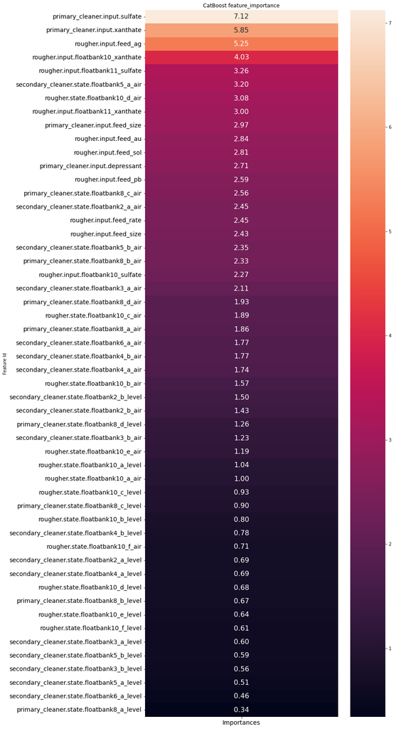

```python
# Визуализируем взаимосвязи
plt.figure(figsize=(10,30))
sns.heatmap((catb.get_feature_importance(prettified=True).set_index('Feature Id')),
            annot=True,
            fmt=".2f",
            annot_kws={'fontsize': 16}
           )
plt.xticks(fontsize = 14)
plt.yticks(fontsize = 14)
plt.title('CatBoost feature_importance')
plt.show()
```

Мы получили похожую на предсказания PHIK важность фичей с некоторыми нюансами (в порядке убывания):

- primary_cleaner.input.sulfate
- primary_cleaner.input.xanthate
- rouger.input.feed_ag
- rougher.input.floatbank10_xanthate
- rougher.input.floatbank11_sulfate
- secondary_cleaner.state.floatbank5_a_air
- rougher.state.floatbank10_d_air

Таким образом модель CatBoost смогла выявить важность зависимостей от солей, реагентов, расхода воздуха на разных этапах технологического процесса. Это очень ценная информация, т.к. используя ее заказчик сможем проводить виртуальные эксперименты (изменяя параметры реактивов и параметры оборудования), что поможет без ущерба для бюджета реализовать усовершенствование процесса и увеличить прибыль.

## Итоговый вывод

**Разведочный анализ:**

- Имеющиеся данные высокого качества: особых проблем, больших выбросов, ошибок записи, дублей не обнаружено
- Есть пропуски в данных. Доля пропусков в среднем не более 5%, максимальная доля пропусков в secondary_cleaner.output.tail_sol 8.99%.
- В условии задачи сказано, что соседние по времени параметры часто похожи. Поэтому наиболее оптимальным представляется решение - заменить пропуски значениями ближайших соседей fillna(method='ffill').

По условиям задачи:

- Некоторые параметры недоступны, потому что замеряются и/или рассчитываются значительно позже. Из-за этого в тестовой выборке отсутствуют некоторые признаки, которые могут быть в обучающей. Также в тестовом наборе нет целевых признаков.

Обнаружено:

- В тестовой выборке отсутствуют показания по концентрации золота, Ag, Pb и солей в продукте и отвальных хвостах для всех этапов технологического процесса. По условию задачи в тестовом наборе нет целевых признаков.
- Также в тестовой выборке отсутствуют некоторые вычисляемые параметры, которые определяют отношение ряда элементов к золоту на этапе флотации. Скорее всего это те параметры, котрые по условию задачи измеряются и/или вычисляются на последующих этапах:
  - rougher.calculation.sulfate_to_au_concentrate
  - rougher.calculation.floatbank10_sulfate_to_au_feed
  - rougher.calculation.floatbank11_sulfate_to_au_feed
  - rougher.calculation.au_pb_ratio

Решаемая нами в рамках проекта задача:

- Предсказать коэффициент восстановления золота из золотосодержащей руды. В вашем распоряжении данные с параметрами добычи и очистки. Логично, что если у нас нет расчетных формул для 4-х измеряемых и/или вычисляемых на последующих этапах параметров, их не следует учитывать при обучении модели.

**Итог:**

- Данные подготовлены для обучения моделей. Пропуски обработаны. Ошибок нет.
- В обучающей выборке оставлены только те параметры, которые присутствуют в тестовой.
- Отсутствующие в тестовой выборке целевые признаки были добавлены из полных данных, чтобы была возможность проверки качества предсказаний моделей.
- Был подготовлен отдельный набор данных с масштабированными фичами методом StandardScaler() как попытка улучшить качество предсказаний некоторых моделей.

**Оценка суммарной концентрации всех веществ на различных этапах очистки:**

- После каждой из степеней очистки суммарная концентрация Au, Ag, Pb равномерно нарастает. Разброс значений параметра становится меньше.
- Суммарное количество Au, Ag, Pb в отвальных хвостах после каждой стадии не линейно. Меньше всего хвосты после флотации, больше всего после первой стадии очистки. Разброс значений суммарной концентрации Au, Ag, Pb в отвальных хвостах после 1 этапа самый большой.
- Наблюдаются небольшие выбросы. Есть некоторый отличимый всплеск около нулевых значений как в основном продукте, так и в отвальных хвостах. Это может быть как следствием рабочего процесса (технологическое обслуживание аппаратов при работающих измерителях), так и следствием обработки неудачно взятой породы.

**Распределение размера гранул сырья на обучающей и тестовой выборках:**

Значения размера гранул очень похожи в тестовой и обучающей выборках. Среднее значение и медиана практически совпадают. На фходе этапа флотации есть большие выбросы, но к этапу первой очистки мы получаем весьма равномерное нормальное распределение практически без выбросов. Проблем не наблюдается.

**Выбор модели предсказания:**

Были обучены следующие модели:

- CatBoost
- KNeighbors
- Линейная регрессия
- Ridge регрессия
- XGBoost

Лучше всего себя показала модель **KNeighbors**:

- sMAPE == 7.307143407392578 (на реальных данных)
- sMAPE == 5.894494906467981 (на масштабированных фичах)

Однако стоит помнить, что модель KNeighbors фактически не обучается, а изучает тренировочную выборку. Т.е. Модель просто находит значение в нашем случае по 3 ближайшим соседям с минимальными расстояниями. Если процесс консервативный, мало подвежен изменениям (как это говорится в условиях задачи) - такую модель можно использовать.

Если модель разрабатывается с целью так же проводить какие-то эксперименты (эксперименты в реальном техпроцессе с золотом наверное будут стоить оченьдорого), использоваться универсально для разных пород и условия - такая модель вряд ли подойдет. Поэтому не будем придавать большое значение ее текущим результатам.

При этом у обеих моделей градиентного бустинга ощущается большое потенциал. Если увеличить количество итераций, снизить learning rate - можно получить результат намного лучше. Кроме того есть и другие параметры, например тот же max_depth должен иметь большое значение.

Скорость обучения **XGBoost** намного выше, чем у **CatBoost**. Это важный параметр, т.к. у нас много фичей, два таргета, датасет тяжелый. Если мы будем накручивать количество итераций, время обучения будет более чем значительным. Если для заказчика приемлема погрешность и требуется часто переобучать модель - лучше XGBoost. Но качество предсказаний и стабильность у CatBoost выше.

Отдаем предпочтение **CatBoost**, т.к. у него гораздо больше возможностей по доводке, и в конечном итоге, он должен дать результат еще лучше. Особенно если подбираться параметры, например, через Optuna. А еще можно использовать встроенную CV, чтобы определить лучшую итерацию (момент переобучения). Но у нас учебный проект и ограниченные ресурсы. Поэтому просто берем **CatBoost** с теми настройками, которые уже были получены.

Линейные модели дают весьма слабый результат.

**Результат анализа полученной модели:**

Мы получили похожую на предсказания PHIK важность фичей с некоторыми нюансами (в порядке убывания):

- primary_cleaner.input.sulfate
- primary_cleaner.input.xanthate
- rouger.input.feed_ag
- rougher.input.floatbank10_xanthate
- rougher.input.floatbank11_sulfate
- secondary_cleaner.state.floatbank5_a_air
- rougher.state.floatbank10_d_air

Таким образом модель CatBoost смогла выявить важность зависимостей от солей, реагентов, расхода воздуха на разных этапах технологического процесса. Это очень ценная информация, т.к. используя ее заказчик сможем проводить виртуальные эксперименты (изменяя параметры реактивов и параметры оборудования), что поможет без ущерба для бюджета реализовать усовершенствование процесса и увеличить прибыль.

**Рекомендации:**

В рамках учебного проекта сложно обучать большие модели на тяжелых данных. Модель еще можно улучшить. Для этого можно попробовть подобрать параметры, например, через Optuna. Если мощности и время позволяют - лучше перебирать не грубые дискретные параметры, а с небольшим шагом. Это позволит значительно улучшить результат. Потенциал есть.